# Autonomous Driving Object Recognition Using Convolutional Neural Networks

- Author: Robert Lartigue

```python
# Import packages neeed for this assignment
import pandas as pd
import numpy as np
import matplotlib.pyplot as plt
import seaborn as sns
import pickle

from sklearn.preprocessing import LabelEncoder
from sklearn.preprocessing import MinMaxScaler, StandardScaler
from sklearn.metrics import confusion_matrix, accuracy_score, f1_score
from sklearn.model_selection import StratifiedKFold
from sklearn.metrics import roc_curve, auc
from scipy import interp


import keras
from keras.models import Sequential, Input, Model, load_model
from keras.layers import Dense, Dropout, Activation, Flatten, Reshape, Conv2D, MaxPooling2D, average
from keras.preprocessing.image import ImageDataGenerator
from keras.callbacks import EarlyStopping
from keras.regularizers import l2
from keras.utils import to_categorical
from keras.layers.normalization import BatchNormalization
from keras.layers import Add
```

```python
# Helper function used to plot the confusion matricies of the CNN's in this assignment.
def summarize_net(net, X_test, y_test, title_text = ''):
    plt.figure(figsize = (15,10))
    yhat = np.argmax(net.predict(X_test), axis = 1)
    f1 = f1_score(y_test, yhat, average = 'micro')
    cm = confusion_matrix(y_test, yhat)
    cm = cm/np.sum(cm, axis = 1)[:, np.newaxis]
    sns.heatmap(cm, annot = True, fmt = '.2f', cmap = 'Blues')
    plt.title(f'{title_text} : F1 Score {f1}')
    plt.show()

# Code Reference: Eric Larson: notebooks/Machine%20Learning%20In%20Python/EricLarson/12.%20More%20Advanced%20CNN%20Techniques.ipynb
```

# 1. Dataset

In this lab I will use convolutional neural networks (CNNs) to perform object classification on a subset of the CIFAR-100 dataset. The CIFAR-100 dataset consists of tiny 32x32 pixel thumbnail images collected by Alex Krizhevsy, Vinod Nair, and Geoffrey Hinton for a paper entitled 'Learning Multiple Layers of Features from Tiny Images' by Alex Krizhevsky, 2009[2]. The table below shows the superclasses and classes of the images in the dataset.

[1] https://www.cs.toronto.edu/~kriz/cifar.html

[2] https://www.cs.toronto.edu/~kriz/learning-features-2009-TR.pdf

| Superclass | Classes |
| --- | --- |
| aquatic mammals | beaver, dolphin, otter, seal, whale |
| fish | aquarium fish, flatfish, ray, shark, trout |
| flowers | orchids, poppies, roses, sunflowers, tulips |
| food | containers bottles, bowls, cans, cups, plates |
| fruits and vegetables | apples, mushrooms, oranges, pears, sweet peppers |
| household electrical devices | clock, computer keyboard, lamp, telephone, television |
| household furniture | bed, chair, couch, table, wardrobe |
| insects | bee, beetle, butterfly, caterpillar, cockroach |
| large carnivores | bear, leopard, lion, tiger, wolf |
| large man-made outdoor things | bridge, castle, house, road, skyscraper |
| large natural outdoor scenes | cloud, forest, mountain, plain, sea |
| large omnivores and herbivores | camel, cattle, chimpanzee, elephant, kangaroo |
| medium-sized mammals | fox, porcupine, possum, raccoon, skunk |
| non-insect invertebrates | crab, lobster, snail, spider, worm |
| people | baby, boy, girl, man, woman |
| reptiles | crocodile, dinosaur, lizard, snake, turtle |
| small mammals | hamster, mouse, rabbit, shrew, squirrel |
| trees | maple, oak, palm, pine, willow |
| vehicles 1 | bicycle, bus, motorcycle, pickup truck, train |
| vehicles 2 | lawn-mower, rocket, streetcar, tank, tractor |

# 2. Business Case

Autonomous cars are unmanned vehicles capable of driving without human interaction. In order to enable them to do this, autonomous cars must excellent at detecting and making sense of their surroundings. To do this, a variety of techniques such as radar, laser light, GPS, odometry, and computer vision are all utilized.

In this lab I will develop an object classification model, using convolutional nerual networks, that can be deployed in autonoumous driving vehicles to enhance their abillity to detect and interpret their surroundings. The prediction task of this object classification model is to classify objects autonomous driving vehicles are likely to encouter while driving. Therefore, I will only use a subset of the classes in the CIFAR-100 dataset representative of objects cars are likely to encounter while the road. From the dataset's superclass and class description above, I will use the classes 'people', 'trees', 'large man-made outdoor things', and 'vehicles 1', as the classes of objects I would like the algorithm to classify. Please note I chose to use the superclasses of the objects as opposed to the individual classes in order to limit the number of classes the algorithm would need to decipher between. If this model were to be used in practice, this would not be the realistic case and the individual classes of the objects would need to be utilized.

Because CIFAR-100 consists of tiny 32x32 pixel thumbnail images, this particular object classification model will focus on detecting and classifying these object from a distance. Thus, this would allow autonomous driving vehicles to detect and classify images from a long way away, while objects captured on the car's cameras may still be small, and give the car adequate time to make a decision reagarding the object.

The baseline this algorithm would need to beat is difficult to pinpoint. For this lab I am going to argue that in order for this algorithm to be deployable it needs to be 100% accurate in classifing these objects as there is really no room for error in the case of self driving cars. In practice this algorithm would be trained and deployed in autonomous driving vehicles to provide the vehicle with real time prediction regarding the objects in its surroundings.

Possible third party users would be companies such as Tesla, Uber, Apple, Google, and Waymo, to name a few, who are all currently competing to develop self driving vehicles.

[3] https://www.techrepublic.com/article/apples-autonomous-car-software-uses-neural-networks-to-improve-navigation-object-detection/ [4] https://www-cs.stanford.edu/people/teichman/papers/arso2011.pdf

# 2. Data Preparation

#### 2.1 Load the Dataset

```python
def unpickle(file):
    with open(file, 'rb') as pick:
        dict = pickle.load(pick, encoding='bytes')
    return dict

# Code Reference: https://www.cs.toronto.edu/~kriz/cifar.html
```

```python
# Load the training and test data
train = unpickle('cifar-100-python/train')
test = unpickle('cifar-100-python/test')
meta = unpickle('cifar-100-python/meta')
```

```python
# Load the corresponding label names of the images
label_names = meta[b'coarse_label_names']
```

```python
idx = 0
label_map = []
for coarse_label_numer in train[b'coarse_labels']:
    label_map.insert(idx, (coarse_label_numer, label_names[coarse_label_numer]))
    idx += 1

label_map_df = pd.DataFrame(label_map, columns = ['Coarse_Label_Number', 'Coarse_Label_Name'])
label_map_df = label_map_df.drop_duplicates()
label_map_df = label_map_df.sort_values(by='Coarse_Label_Number')
label_map_df.reset_index(drop = True, inplace = True)
label_map_df
```

|  | Coarse_Label_Number | Coarse_Label_Name |
| --- | --- | --- |
| 0 | 0 | b'aquatic_mammals' |
| 1 | 1 | b'fish' |
| 2 | 2 | b'flowers' |
| 3 | 3 | b'food_containers' |
| 4 | 4 | b'fruit_and_vegetables' |
| 5 | 5 | b'household_electrical_devices' |
| 6 | 6 | b'household_furniture' |
| 7 | 7 | b'insects' |
| 8 | 8 | b'large_carnivores' |
| 9 | 9 | b'large_man-made_outdoor_things' |
| 10 | 10 | b'large_natural_outdoor_scenes' |
| 11 | 11 | b'large_omnivores_and_herbivores' |
| 12 | 12 | b'medium_mammals' |
| 13 | 13 | b'non-insect_invertebrates' |
| 14 | 14 | b'people' |
| 15 | 15 | b'reptiles' |
| 16 | 16 | b'small_mammals' |
| 17 | 17 | b'trees' |
| 18 | 18 | b'vehicles_1' |
| 19 | 19 | b'vehicles_2' |

```python
# Mapping of label numbers to label names I want to identify in this dataset
people_coarse_label = 14
trees_coarse_label = 17
vehicles1_coarse_label = 18
large_manmade_outdoor_things_coarse_label = 9
```

#### 2.2 Create Training and Testing Dataset with People, Trees, and Vehicle Images

The for loops below iterate through the training and testing data and select images only with the superclasses needed for this classification task.

```python
X_train = []
X_test = []
y_train = []
y_test = []

# Create training data
for coarse_label, idx_train in zip(train[b'coarse_labels'], range(len(train[b'coarse_labels']))):
    if coarse_label == people_coarse_label:
        X_train.append(train[b'data'][idx_train])
        y_train.append(train[b'coarse_labels'][idx_train])
    elif coarse_label == trees_coarse_label:
        X_train.append(train[b'data'][idx_train])
        y_train.append(train[b'coarse_labels'][idx_train])
    elif coarse_label == vehicles1_coarse_label:
        X_train.append(train[b'data'][idx_train])
        y_train.append(train[b'coarse_labels'][idx_train])
    elif coarse_label == large_manmade_outdoor_things_coarse_label:
        X_train.append(train[b'data'][idx_train])
        y_train.append(train[b'coarse_labels'][idx_train])


# Create testing data
for coarse_label, idx_test in zip(test[b'coarse_labels'], range(len(test[b'coarse_labels']))):
    if coarse_label == people_coarse_label:
        X_test.append(test[b'data'][idx_test])
        y_test.append(test[b'coarse_labels'][idx_test])
    elif coarse_label == trees_coarse_label:
        X_test.append(test[b'data'][idx_test])
        y_test.append(test[b'coarse_labels'][idx_test])
    elif coarse_label == vehicles1_coarse_label:
        X_test.append(test[b'data'][idx_test])
        y_test.append(test[b'coarse_labels'][idx_test])
    elif coarse_label == large_manmade_outdoor_things_coarse_label:
        X_test.append(test[b'data'][idx_test])
        y_test.append(test[b'coarse_labels'][idx_test])
```

```python
y_train_labels = [label_names[idx] for idx in y_train]
y_test_labels = [label_names[idx] for idx in y_test]
```

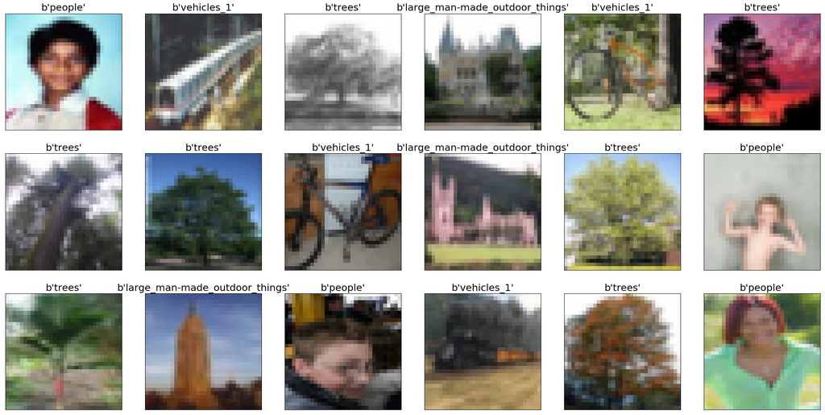

```python
def plot_gallery(images, labels, n_rows = 3, n_cols = 6):
    plt.figure(figsize = (5 * n_cols, 5 * n_rows))

    for i in range(n_rows * n_cols):
        plt.subplot(n_rows, n_cols, i + 1)
        plt.imshow(np.rot90(X_train[i].reshape((3,32,32)).T, k = 1, axes = (1,0)))
        plt.title(y_train_labels[i], size = 20)
        plt.xticks([])
        plt.yticks([])
    plt.show()

plot_gallery(X_train, y_train_labels)
```

Above shows a sample of the images and class labels that the CNNs in this assignment are attempting to classify.

#### 2.3 Preprocess Data

```python
# Convert all training and test sets from lists to arrays
X_train = np.array(X_train)
y_train = np.array(y_train)
X_test = np.array(X_test)
y_test = np.array(y_test)
```

```python
# Label Encode y_train and y_test
from sklearn.preprocessing import LabelEncoder
LE = LabelEncoder()
y_train = LE.fit_transform(y_train)
y_test = LE.fit_transform(y_test)
```

Below is the numeric class label mapping to the class label names:

| Class | Description |
| --- | --- |
| Class 0 | Large man-made outdoor things |
| Class 1 | People |
| Class 2 | Trees |
| Class 3 | Vehicles |

#### 2.4 Min Max Scaling the Data

Before passing the data to the convolutional neural network, the pixel values need to be scaled as to not saturate the neurons and allow the network to properly train. To bring the pixel values onto the same scale there are two approaches one could take: normalization (Min-Max Scaling) or standardization (Standard Scaling). Because I am working with image data, I will use Min Max Scaling to bring the pixels across all images onto the same scale, between 0 and 1. This is because, when working with images the data should be normalized and not standardized. Mathematically the normalization I will perform on the images is shown below:

$$ xnorm^{i} = \frac{x^{i} - xmin} {xmax - xmin} $$

where x superscript i is a particular pixel values and xmin and xmax are the maximum and minimum values pixel values in the image.

Below, I show the effect that of both normalization and standardization has on the images. It is clear from the images below that normalization yields better image quality than standardization.

```python
# Normalization
mms = MinMaxScaler()
X_train = mms.fit_transform(X_train)
X_test = mms.transform(X_test)
```

```python
# Standardizaition
ss = StandardScaler()
X_train_standardscaled = ss.fit_transform(X_train)
```

```
Clipping input data to the valid range for imshow with RGB data ([0..1] for floats or [0..255] for integers).
```

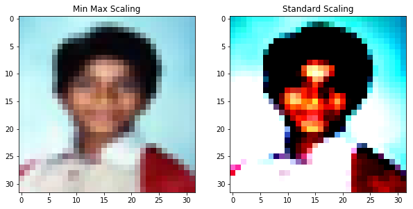

```python
plt.figure(figsize = (10,10))
plt.subplot(121)
plt.title('Min Max Scaling')
plt.imshow(np.rot90(X_train[0].reshape((3,32,32)).T, k = 1, axes = (1,0)))
plt.subplot(122)
plt.title('Standard Scaling')
plt.imshow(np.rot90(X_train_standardscaled[0].reshape((3,32,32)).T, k = 1, axes = (1,0)))
plt.show()
```

# 3. Evaluation Metric

In choosing an appropriate evaluation metric in which to evaluate this algorithms performance, we must understand how this algorithm would be used in a deployed model. Lets consider an example to bring to light the appropriate evaluation metric for this model.

Consider Uber has placed our deployed model in their new taxis. Their reason for using our model is two fold. One, they want their cars to drive safely and be able to detect and avoid collisions with object cars are likely to encounter while driving, and two, they want to identify people who are waiting for thier uber cabs so they can pick up their customers.

Looking at fold one above, the clear evaluation metric is recall. That is, we would want our algorithm to avoid false negatives, for example in order to avoid the case of our algorithm predicting a person is not a person, or a bicycle is not a bicycle, and coming into collision with either of the two. In considering the case where a false negative is predicted by the algorithm, this would be catastrophic for a self driving vehicle, and could result in fatal consequences for pedestrians in the vicinity of the vehicle, or for the passengers in the car.

In considering fold two above, the clear evaluation metric is precision. That is, we want our algorithm to avoid predicting false positives. For example, predicting a sidewalk advertisement containing a picture of a person is actually a person waiting for their cab. In examining the case of predicting false positives more closely, the car would not operate very efficiently if it was stopping to pick up customers who it believed were people but were actually just pictures of people. With this it came to my attention that the CIFAR-100 dataset may not be the most realistic image data to train an autonomous driving vehicle classification model on since it is simply pictures of things. For instance, by using the CIFAR-100 images to train the CNN to classify people, if it saw an advertisement with a picture of a person on it, this would probably look similar to the images used to train the model, thus the model would not be wrong in predicting a picture of a person is an actual person because that is EXACTLY how it was trained. However, keep this in mind and lets put this aside for now.

From the above it is seen that a combination of both precision and recall are important to the fluid and cohesive operation of a self driving Uber, as in the example. As a result of this, the appropriate evaluation metric in which to evaluate this algorithms performance is the F1-Measure, which is defined mathematically as below:

$$ F1-Measure\hspace{1mm}(F) = \frac{2\hspace{0.2mm}r\hspace{0.2mm}p} {r\hspace{0.2mm}p}$$

where, recall (r) and precision (p) are defined as:

$$ Precision\hspace{1mm}(p) = \frac{True\hspace{1mm} Positives} {True\hspace{1mm} Positives\hspace{1mm} + \hspace{1mm}False\hspace{1mm}Positives}$$$$ Recall\hspace{1mm}(r) = \frac{True\hspace{1mm} Positives} {True\hspace{1mm} Positives\hspace{1mm} + \hspace{1mm}False\hspace{1mm}Negatives}$$

With the F1-Measure, there are a few averaging options in which to choose from to better tailor the F1-Measure for this dataset and classification task. In choosing whether to 'micro', 'macro', or 'weighted' average the F1-Measure, we must consider the class distribution of the dataset. Lets do so below:

```python
#

import plotly
plotly.offline.init_notebook_mode() # run at the start of every notebook

graph1 = {'labels': np.unique(y_train),
          'values': np.bincount(y_train),
            'type': 'pie'}
fig = dict()
fig['data'] = [graph1]
fig['layout'] = {'title': 'Class Distribution',
                'autosize':False,
                'width':500,
                'height':300}

plotly.offline.iplot(fig)

# Code Refernce: Eric, Larson: http:notebooks/Machine%20Learning%20In%20Python/EricLarson/05.%20Logistic%20Regression.ipynb
```

[interactive chart not shown]

From the figure above, it is seen that the class distribution in the dataset is equal at 25 percent across all classes. Thus, we do not need to account for any class imbalance averaging in the F1-Measure. However, because we are performing multi-classification, we need a way to combine our F1-Measure for multiple classes, using either a micro or macro average. Because there is an equal number of instances in each class, I chose to use a micro averaged F1-Measure, which weights all instances equally.

# 4. Method for Dividing Data into Training and Test Splits

In choosing the appropriate method in which to divide the data for this classification task into training and testing splits, we must consider the the amount of data we have to work with, and how this algorithm will be used in a deployed model.

In addressing the amount of data I have to work with, the original CIFAR-100 dataset consists of 60,000 images, which is a large amount of data. However, because I chose a subset of the CIFAR-100 dataset for application in the autonomous driving industry, the dataset I am left with is comprised of 12,000 images. While this is still a good amount of data, in training convolutional neural networks, it is helpful to have lots of data to train these algorithms for good generalization performance. Thus, in order to make efficient use of the 12,000 images in my dataset, I chose to use Stratified 10-fold cross validation. K-fold cross validation efficiently uses small amounts of data to train and test algorithms by training the algorithm on K-1 folds and testing the algorithm on the remaining fold. Thus, even though I am limited to 12,000 images, using 10-Fold cross validation ensures the algorithm will be trained and testing over vast amounts of data.

This cross validation technique accurately represents how this algorithm would be used in practice for the following reasons: In a deployed model, for this algorithm to even be considered deployable, as discussed in the business case, it would need to achieve 100% classification accuracy all the time. Because K-Fold cross validation trains and tests the algorithm across a vast amount of data, it gives an accurate measure for the generalization performance of an algorithm. Thus, we can see how the algorithm performs across varying instances as it would be subjected to in a deployed model. Therefore, I believe stratified K-Fold cross validation most accurately reflects how this algorithm would be used when deployed in a self driving car.

However, because performing 10-fold cross validation would take hours to run when training some of the CNNs below, for the sake of time and getting this lab done, I will use 2 fold cross validation, which should still give us a descent gauge of the generalization performance of the models. Also, it should be noted that using data expansion below, I actually doubled the size of my training data, which makes 2 fold cross validation even more appropriate in the context due to the large amount of training data.

# 5. Data Augmentation and Expansion

As discussed in business case, this dataset is composed of images of people, trees, large man-made outdoor things, and vehicles, inherited from the CIFAR-100 dataset. The convolutional neural networks in this assignment aim to classify these objects for use in autonomous driving vehicles to enable them to better understand their surroundings.

The CIFAR-100 is somewhat unrealistic training data to use for the training a classification algorithm for a self driving vehicle. It consists of cenetered images, containing the whole object, with appropriate orientations, which really does not accurately reflect what a camera on a self driving car would see while driving. However, we do not have to be completely limited by the images we are given. Using data augmentation techniques, we can alter the images from the CIFAR-100 dataset to more accurately represent images a self driving car's camera would capture.

For instance, when a car is driving it may capture a bicycle traveling from right to left or left to right according to its perspective. This goes for all vehicles a car may encounter on the road such as trucks, motorcycles, ect... Thus, it would make sense to flip some images around the y-axis (horizontally) to depict the various directions cars, bikes, and motorcycles could be traveling.

Also, the cameras in autonomous driving vehicles may not always capture the full object in one single frame. Meaning sometimes the camera may only detect half a bicycle or car. To depict this in the original images, it would be sensible to shift the location of the image in the frame, either up or down in the frame, or left and right, or perhaps both.

Another scenario that should be accounted for is the distance these objects are from the car at the time they are caught on the cars camera. To account for this, the zoom of the images should be altered to reflect objects that are in a close proximity to the car and objects that are very far away from the car at the time they are detected by the cars camera.

A way to account for these occurrences is, as mentioned above, to use image augmentation and data expansion. Using the built-in keras ImageDataGenerator I will create a new set of augmented images, reflecting the scenarios discussed above. Doing so, I will double the size of my image data (data expansion) by creating 10,000 new augmented images, according to the augmentations above, and append them to the original images.

In the ImageDataGenerator below, I will set the following parameters to represent the image augmentations discussed above:

1) rotation_range to 5: to represent object that have imperfect orientations in the cars camera

2) width and height shift range to 0.1: to represent objects that may have not been fully caught in the cars camera

5) cval to 0.1: to better fill the pixel values outside the boundaries in appropriate cases

```python
datagen = ImageDataGenerator(rotation_range = 5,
    width_shift_range = 0.1,
    height_shift_range = 0.1,
    zoom_range = 0.1,
    cval = 0.1,
    horizontal_flip = True)
```

```python
X_train_aug = X_train.reshape(-1,32,32,3)
X_test_aug = X_test.reshape(-1,32,32,3)
y_train_aug = y_train
y_test_aug = y_test
```

```python
datagen.fit(X_train_aug)
```

```python
for e in range(1):
    batches = 0
    for X_batch, y_batch in datagen.flow(X_train_aug, y_train, batch_size = 1000):
        X_train_aug = np.concatenate((X_train_aug, X_batch), axis = 0)
        y_train_aug = np.concatenate((y_train_aug, y_batch), axis = 0)
        batches += 1
        if batches >= len(X_train) / 1000:
            break
# Code Reference: https://www.kaggle.com/camnugent/expanded-training-set-keras-imagedatagenerator
```

```python
n_classes = 4
y_train_ohe = keras.utils.to_categorical(y_train, num_classes = n_classes)
y_test_ohe = keras.utils.to_categorical(y_test, num_classes = n_classes)
y_train_aug_ohe = keras.utils.to_categorical(y_train_aug, n_classes)
y_test_aug_ohe = keras.utils.to_categorical(y_test_aug, n_classes)
```

```python
print(X_train_aug.shape)
print(y_train_aug.shape)
```

```
(20000, 32, 32, 3)
(20000,)
```

Before we begin the exploration of different CNN architectures, lets test our augemented data on a very simple CNN.

```python
# This block of code will not be run becuase the model is now saved
cnn = Sequential()
cnn.add(Conv2D(filters = 16,
              input_shape = (32,32,3),
              kernel_size = (3,3),
              padding = 'same',
              activation = 'relu'))

cnn.add(MaxPooling2D(pool_size = (2,2), data_format = 'channels_last'))

cnn.add(Flatten())
cnn.add(Dense(n_classes, activation = 'softmax'))
```

```python
# This block of code will not be run because the model is saved
cnn.compile(loss='mean_squared_error',
              optimizer='rmsprop',
              metrics=['accuracy'])

cnn.fit(X_train_aug, y_train_aug_ohe,
        batch_size=32, epochs=10,
        shuffle=True, verbose=1)
```

```python
#cnn.save('CNN/cnn.h5')
```

```python
cnn = load_model('CNN/cnn.h5')
```

```python
cnn.summary()
```

```
_________________________________________________________________
Layer (type)                 Output Shape              Param #
=================================================================
conv2d_5 (Conv2D)            (None, 32, 32, 16)        448
_________________________________________________________________
max_pooling2d_5 (MaxPooling2 (None, 16, 16, 16)        0
_________________________________________________________________
flatten_5 (Flatten)          (None, 4096)              0
_________________________________________________________________
dense_5 (Dense)              (None, 4)                 16388
=================================================================
Total params: 16,836
Trainable params: 16,836
Non-trainable params: 0
_________________________________________________________________
```

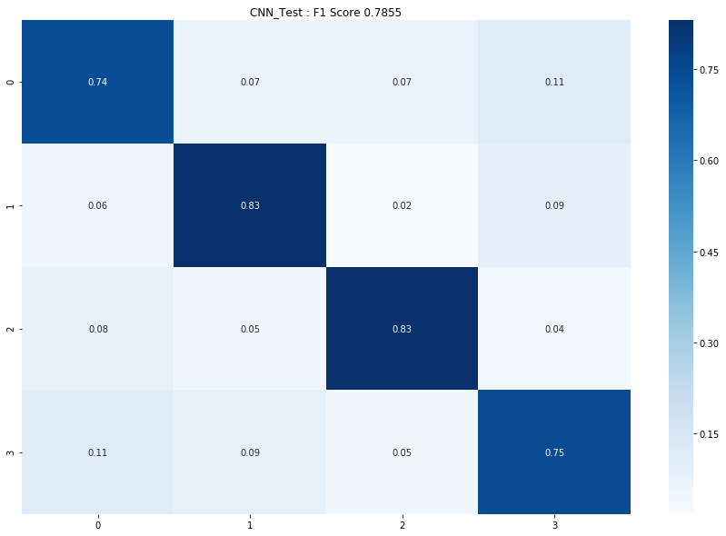

```python
summarize_net(cnn, X_test_aug, y_test, title_text = 'CNN_Test')
```

From the very simple CNN above, we can see that our augmented data is working in our CNN! Now that we know this works, let move onto modeling and exploring different architectures.

# 6. Modeling and Exploring Different CNN Architectures

In this section I am going to explore some different concolutional neural network architectures and investigate a few of the parameters of each architecture as well. In class we discussed a variety of neural network architectures, such as AlexNet, VGG, LeNet, and Resnet, to name a few, each comprised of a different layer makeup. While it would be fun to test all these different architectures, it would be timely and out of the scope of resources for my desktop. However, in exploring a few architectures below, we can use inspirations from these well known CNNs to make architecture changes.

It should be noted that because training the convolutional neural networks takes a substantial amount of time, I trained the models once and the saved the models and the results. Thus at the beginning of each architecture you will see the def create_cnnx which is the architectural code of the CNN and following that the K-Fold cross validation loop I used to train and test the CNN. Following that, you will see a block of code that loads in the trained model and the f1 score over the 2-fold cross validation loops.

#### 6.1 Architecture 1: Class Example (cnn0)

To begin, lets start with a fairly simple CNN. The following CNN is an architecture we looked at in class to classify the fashion MNIST dataset. It consists of 2 convolutional layers and two max pooling layers, generated by the for loop in the code below. Following the convolutional and max pooling layers are a flattening layer and two dense layers. A detailed description of the layer structure for this architecture can be found in the cnn0.summary() below.

```python
def create_cnn0():
    cnn0 = Sequential()

    num_filt_layers = [24, 48]
    for num_filters in num_filt_layers:
        cnn0.add(Conv2D(filters = num_filters,
                        input_shape = (32,32,3), # Channels last!!!
                        kernel_size = (3,3),
                        padding = 'same'))
        cnn0.add(Activation('relu'))
        cnn0.add(MaxPooling2D(pool_size = (2,2), data_format = 'channels_last'))

    cnn0.add(Flatten())
    cnn0.add(Dense(100))
    cnn0.add(Activation('relu'))
    cnn0.add(Dense(n_classes))
    cnn0.add(Activation('softmax'))

    return cnn0

# Code Reference: Eric Larson. http://localhost:8888/notebooks/Machine%20Learning%20In%20Python/EricLarson/11.%20Convolutional%20Neural%20Networks.ipynb
# Copy TensorFlow Architecture from
#   Deep MNIST for experts
#   https://www.tensorflow.org/versions/r0.11/tutorials/mnist/pros/index.html

# Manipulated to mirror parts of this network:
#   http://ankivil.com/mnist-database-and-simple-classification-networks/
```

```python
K = 2

skf = StratifiedKFold(n_splits = K, shuffle = True, random_state = 1).split(X_train_aug, y_train_aug)

F1_score_list_cnn0 = []

for i, (train, test) in enumerate(skf):
    print('Fold:', i)

    X_train_cnn0 = X_train_aug[train]
    y_train_cnn0 = to_categorical(y_train_aug[train], n_classes)
    X_test_cnn0 = X_train_aug[test]
    y_test_cnn0 = to_categorical(y_train_aug[test], n_classes)

    cnn0 = create_cnn0()

    cnn0.compile(loss = 'mean_squared_error',
             optimizer = 'rmsprop',
             metrics = ['accuracy'])

    history_cnn0 = cnn0.fit(X_train_cnn0, y_train_cnn0,
         batch_size = 500, epochs = 50,
         shuffle = True, verbose = 1, validation_data = (X_test_cnn0, y_test_cnn0))

    yhat_cnn0 = np.argmax(cnn0.predict(X_test_cnn0), axis = 1)

    F1_score = f1_score(y_train_aug[test], yhat_cnn0, average = 'micro')

    F1_score_list_cnn0.append(F1_score)

    print('F1 Score:', F1_score)
```

```python
# # Save Model, History, and F1 Score list
# cnn0.save('CNN0/cnn0.h5')
# pickle.dump(F1_score_list_cnn0, open('CNN0/F1_score_list_cnn0.txt', 'wb'))
# pickle.dump(history_cnn0.history, open('CNN0/history_cnn0.txt', 'wb'))
```

```python
cnn0 = load_model('CNN0/cnn0.h5')
f1_score_cnn0 = pickle.load(open('CNN0/F1_score_list_cnn0.txt', 'rb'))
history_cnn0 = pickle.load(open('CNN0/history_cnn0.txt', 'rb'))
```

```python
cnn0.summary()
```

```
_________________________________________________________________
Layer (type)                 Output Shape              Param #
=================================================================
conv2d_3 (Conv2D)            (None, 32, 32, 24)        672
_________________________________________________________________
activation_5 (Activation)    (None, 32, 32, 24)        0
_________________________________________________________________
max_pooling2d_3 (MaxPooling2 (None, 16, 16, 24)        0
_________________________________________________________________
conv2d_4 (Conv2D)            (None, 16, 16, 48)        10416
_________________________________________________________________
activation_6 (Activation)    (None, 16, 16, 48)        0
_________________________________________________________________
max_pooling2d_4 (MaxPooling2 (None, 8, 8, 48)          0
_________________________________________________________________
flatten_2 (Flatten)          (None, 3072)              0
_________________________________________________________________
dense_3 (Dense)              (None, 100)               307300
_________________________________________________________________
activation_7 (Activation)    (None, 100)               0
_________________________________________________________________
dense_4 (Dense)              (None, 4)                 404
_________________________________________________________________
activation_8 (Activation)    (None, 4)                 0
=================================================================
Total params: 318,792
Trainable params: 318,792
Non-trainable params: 0
_________________________________________________________________
```

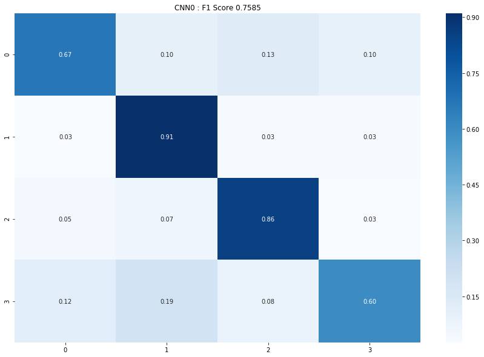

```python
summarize_net(cnn0, X_test_aug, y_test, title_text='CNN0')
```

In exploring the effect that changing a few parameters on the architecture above, lets start simple and focus on just the model evaluation parameters such as the loss function and optimization method. In the cross validation loop below, lets change the loss function to mean_squared_logarithmic_error and the optimization method to adagrad.

###### 6.1.1 CNN0 Modified (cnn0_mod)

```python
def create_cnn0_mod():
    cnn0_mod = Sequential()

    num_filt_layers = [24, 48]
    for num_filters in num_filt_layers:
        cnn0_mod.add(Conv2D(filters = num_filters,
                        input_shape = (32,32,3),
                        kernel_size = (3,3),
                        padding = 'same'))
        cnn0_mod.add(Activation('relu'))
        cnn0_mod.add(MaxPooling2D(pool_size = (2,2), data_format = 'channels_last'))

    cnn0_mod.add(Flatten())
    cnn0_mod.add(Dense(100))
    cnn0_mod.add(Activation('relu'))
    cnn0_mod.add(Dense(n_classes))
    cnn0_mod.add(Activation('softmax'))

    return cnn0_mod

# Code Reference: Eric Larson. http://localhost:8888/notebooks/Machine%20Learning%20In%20Python/EricLarson/11.%20Convolutional%20Neural%20Networks.ipynb
# Copy TensorFlow Architecture from
#   Deep MNIST for experts
#   https://www.tensorflow.org/versions/r0.11/tutorials/mnist/pros/index.html

# Manipulated to mirror parts of this network:
#   http://ankivil.com/mnist-database-and-simple-classification-networks/
```

```python
K = 2

skf = StratifiedKFold(n_splits = K, shuffle = True, random_state = 1).split(X_train_aug, y_train_aug)

F1_score_list_cnn0_mod = []

for i, (train, test) in enumerate(skf):
    print('Fold:', i)

    X_train_cnn0_mod = X_train_aug[train]
    y_train_cnn0_mod = to_categorical(y_train_aug[train], n_classes)
    X_test_cnn0_mod = X_train_aug[test]
    y_test_cnn0_mod = to_categorical(y_train_aug[test], n_classes)

    cnn0_mod = create_cnn0_mod()

    cnn0_mod.compile(loss = 'mean_squared_logarithmic_error',
             optimizer = 'adagrad',
             metrics = ['accuracy'])

    history_cnn0_mod = cnn0_mod.fit(X_train_cnn0_mod, y_train_cnn0_mod,
         batch_size = 500, epochs = 50,
         shuffle = True, verbose = 1, validation_data = (X_test_cnn0_mod, y_test_cnn0_mod))

    yhat_cnn0_mod = np.argmax(cnn0.predict(X_test_cnn0_mod), axis = 1)

    F1_score = f1_score(y_train_aug[test], yhat_cnn0_mod, average = 'micro')

    F1_score_list_cnn0_mod.append(F1_score)

    print('F1 Score:', F1_score)
```

```python
# # Save Model, History, and F1 Score list
# cnn0_mod.save('CNN0_MOD/cnn0_mod.h5')
# pickle.dump(F1_score_list_cnn0_mod, open('CNN0_MOD/F1_score_list_cnn0_mod.txt', 'wb'))
# pickle.dump(history_cnn0_mod.history, open('CNN0_MOD/history_cnn0_mod.txt', 'wb'))
```

```python
cnn0_mod = load_model('CNN0_MOD/cnn0_mod.h5')
f1_score_cnn0_mod = pickle.load(open('CNN0_MOD/F1_score_list_cnn0_mod.txt', 'rb'))
history_cnn0_mod = pickle.load(open('CNN0_MOD/history_cnn0_mod.txt', 'rb'))
```

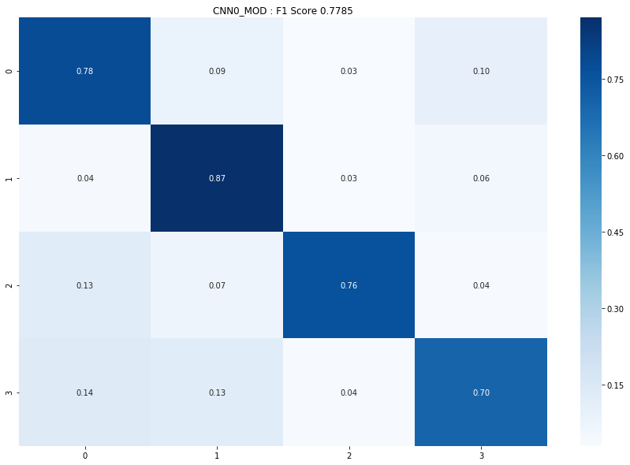

```python
summarize_net(cnn0_mod, X_test_aug, y_test, title_text = 'CNN0_MOD')
```

#### 6.2 Architecture 2: Alex Net Style Architecture (cnn1)

The next architecture I will explore has an AlexNet style convolutional phase with some dropout in the final layers. The main architectural difference in this architecture is the dropout in the final layers. Dropout is a regularization technique used to reduce over-fitting in the CNN. Using dropout, only a subset of the neurons in the network will be trained over each epoch. Thus, not every weight in the model will be updated for each epoch. With dropout I would expect to see a better f1 score using this architecture.

```python
def create_cnn1():
    cnn1 = Sequential()
    cnn1.add(Conv2D(filters = 32,
                  input_shape = (32,32,3),
                  kernel_size = (3,3),
                  padding = 'same',
                  activation = 'relu'))

    cnn1.add(Conv2D(filters = 64,
                   kernel_size = (3,3),
                   padding = 'same',
                   activation = 'relu'))

    cnn1.add(MaxPooling2D(pool_size = (2,2), data_format = 'channels_last'))

    cnn1.add(Dropout(0.25))
    cnn1.add(Flatten())
    cnn1.add(Dense(64, activation = 'relu'))
    cnn1.add(Dropout(0.5))
    cnn1.add(Dense(n_classes, activation = 'softmax'))

    return cnn1

# Code Reference: Eric Larson. http://localhost:8888/notebooks/Machine%20Learning%20In%20Python/EricLarson/11.%20Convolutional%20Neural%20Networks.ipynb
```

```python
K = 2

skf = StratifiedKFold(n_splits = K, shuffle = True, random_state = 1).split(X_train_aug, y_train_aug)

F1_score_list_cnn1 = []

for i, (train, test) in enumerate(skf):
    print('Fold:', i)

    X_train_cnn1 = X_train_aug[train]
    y_train_cnn1 = to_categorical(y_train_aug[train], n_classes)
    X_test_cnn1 = X_train_aug[test]
    y_test_cnn1 = to_categorical(y_train_aug[test])

    cnn1 = create_cnn1()

    cnn1.compile(loss = 'categorical_crossentropy',
             optimizer = 'adagrad',
             metrics = ['accuracy'])

    history_cnn1 = cnn1.fit(X_train_cnn1, y_train_cnn1,
                            batch_size = 500, epochs = 50,
                            shuffle = True, verbose = 1,
                            validation_data = (X_test_cnn1, y_test_cnn1))

    yhat_cnn1 = np.argmax(cnn1.predict(X_test_cnn1), axis = 1)

    F1_score = f1_score(y_train_aug[test], yhat_cnn1, average = 'micro')

    F1_score_list_cnn1.append(F1_score)

    print('F1 Score:', F1_score)
```

```python
# # Save Model, History, and F1 Score list
# cnn1.save('CNN1/cnn1.h5')
# pickle.dump(F1_score_list_cnn1, open('CNN1/F1_score_list_cnn1.txt', 'wb'))
# pickle.dump(history_cnn1.history, open('CNN1/history_cnn1.txt', 'wb'))
```

```python
cnn1 = load_model('CNN1/cnn1.h5')
f1_score_cnn1 = pickle.load(open('CNN1/F1_score_list_cnn1.txt', 'rb'))
history_cnn1 = pickle.load(open('CNN1/history_cnn1.txt', 'rb'))
```

```python
cnn1.summary()
```

```
_________________________________________________________________
Layer (type)                 Output Shape              Param #
=================================================================
conv2d_11 (Conv2D)           (None, 32, 32, 32)        896
_________________________________________________________________
conv2d_12 (Conv2D)           (None, 32, 32, 64)        18496
_________________________________________________________________
max_pooling2d_8 (MaxPooling2 (None, 16, 16, 64)        0
_________________________________________________________________
dropout_7 (Dropout)          (None, 16, 16, 64)        0
_________________________________________________________________
flatten_6 (Flatten)          (None, 16384)             0
_________________________________________________________________
dense_11 (Dense)             (None, 64)                1048640
_________________________________________________________________
dropout_8 (Dropout)          (None, 64)                0
_________________________________________________________________
dense_12 (Dense)             (None, 4)                 260
=================================================================
Total params: 1,068,292
Trainable params: 1,068,292
Non-trainable params: 0
_________________________________________________________________
```

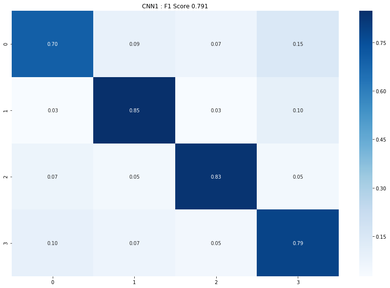

```python
summarize_net(cnn1, X_test_aug, y_test, title_text = 'CNN1')
```

Look at that! Using the AlexNet convolutional phase the overall f1 score of the model increased by another percent. We are moving in the right direction! In the confusion matrix above, we see a more evenly distributed classification accuracy across all classes. Lets look at the training and validation accuracy over the training iterations and see if the dropout helped the network not over-fit the training data.

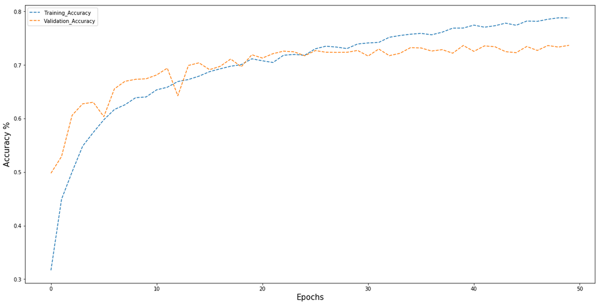

```python
%matplotlib inline
plt.figure(figsize = (20,10))
plt.plot(history_cnn1['acc'], label = 'Training_Accuracy', linestyle = '--')
plt.plot(history_cnn1['val_acc'], label = 'Validation_Accuracy', linestyle = '--')
plt.ylabel('Accuracy %', size = 15)
plt.xlabel('Epochs', size = 15)
plt.legend()
plt.show()
```

Looking at the training and validation accuracy over the training iterations of the network, its seems the dropout helped somewhat in not over-fitting the training data, however we still see validation accuracy lagging towards the end.

In changing a few of the network parameters below, lets add more dropout in the first dropout layer and see if this helps. Also to avoid redundancy in the first and second convolutional layers, I will increase the kernal size in the first convolutional layer.

Also, a parameter we have not looked at yet is the batch size. In the previous models I have purposefully kept the batch size large to help reduce training time, however I believe this could be hindering performance. In the modified network below, lets decrease the batch size form 500 to 200.

Changes:

- Kernal Size in first convolutional layer increased to (6,6) from (3,3)
- Dropout in first dropout layer increasesd to 0.4 from 0.25
- Batch size decreased to 200 from 500

###### 6.2.1 CNN1 Modified (cnn1_mod)

```python
def create_cnn1_mod():
    cnn1_mod = Sequential()
    cnn1_mod.add(Conv2D(filters = 32,
                  input_shape = (32,32,3),
                  kernel_size = (6,6),
                  padding = 'same',
                  activation = 'relu'))

    cnn1_mod.add(Conv2D(filters = 64,
                   kernel_size = (3,3),
                   padding = 'same',
                   activation = 'relu'))

    cnn1_mod.add(MaxPooling2D(pool_size = (2,2), data_format = 'channels_last'))

    cnn1_mod.add(Dropout(0.4))
    cnn1_mod.add(Flatten())
    cnn1_mod.add(Dense(64, activation = 'relu'))
    cnn1_mod.add(Dropout(0.5))
    cnn1_mod.add(Dense(n_classes, activation = 'softmax'))

    return cnn1_mod

# Code Reference: Eric Larson. http://localhost:8888/notebooks/Machine%20Learning%20In%20Python/EricLarson/11.%20Convolutional%20Neural%20Networks.ipynb
```

```python
K = 2

skf = StratifiedKFold(n_splits = K, shuffle = True, random_state = 1).split(X_train_aug, y_train_aug)

F1_score_list_cnn1_mod = []

for i, (train, test) in enumerate(skf):
    print('Fold:', i)

    X_train_cnn1_mod = X_train_aug[train]
    y_train_cnn1_mod = to_categorical(y_train_aug[train], n_classes)
    X_test_cnn1_mod = X_train_aug[test]
    y_test_cnn1_mod = to_categorical(y_train_aug[test])

    cnn1_mod = create_cnn1_mod()

    cnn1_mod.compile(loss = 'categorical_crossentropy',
             optimizer = 'adagrad',
             metrics = ['accuracy'])

    history_cnn1_mod = cnn1_mod.fit(X_train_cnn1_mod, y_train_cnn1_mod,
                            batch_size = 200, epochs = 50,
                            shuffle = True, verbose = 1,
                            validation_data = (X_test_cnn1_mod, y_test_cnn1_mod))

    yhat_cnn1_mod = np.argmax(cnn1_mod.predict(X_test_cnn1_mod), axis = 1)

    F1_score = f1_score(y_train_aug[test], yhat_cnn1_mod, average = 'micro')

    F1_score_list_cnn1_mod.append(F1_score)

    print('F1 Score:', F1_score)
```

```python
cnn1_mod.save('CNN1_MOD/cnn1_mod.h5')
pickle.dump(F1_score_list_cnn1_mod, open('CNN1_MOD/F1_score_list_cnn1_mod.txt', 'wb'))
pickle.dump(history_cnn1_mod.history, open('CNN1_MOD/history_cnn1_mod.txt', 'wb'))
```

```python
cnn1_mod = load_model('CNN1_MOD/cnn1_mod.h5')
f1_score_cnn1_mod = pickle.load(open('CNN1_MOD/F1_score_list_cnn1_mod.txt', 'rb'))
history_cnn1_mod = pickle.load(open('CNN1_MOD/history_cnn1_mod.txt', 'rb'))
```

```python
cnn1_mod.summary()
```

```
_________________________________________________________________
Layer (type)                 Output Shape              Param #
=================================================================
conv2d_3 (Conv2D)            (None, 32, 32, 32)        3488
_________________________________________________________________
conv2d_4 (Conv2D)            (None, 32, 32, 64)        18496
_________________________________________________________________
max_pooling2d_2 (MaxPooling2 (None, 16, 16, 64)        0
_________________________________________________________________
dropout_3 (Dropout)          (None, 16, 16, 64)        0
_________________________________________________________________
flatten_2 (Flatten)          (None, 16384)             0
_________________________________________________________________
dense_3 (Dense)              (None, 64)                1048640
_________________________________________________________________
dropout_4 (Dropout)          (None, 64)                0
_________________________________________________________________
dense_4 (Dense)              (None, 4)                 260
=================================================================
Total params: 1,070,884
Trainable params: 1,070,884
Non-trainable params: 0
_________________________________________________________________
```

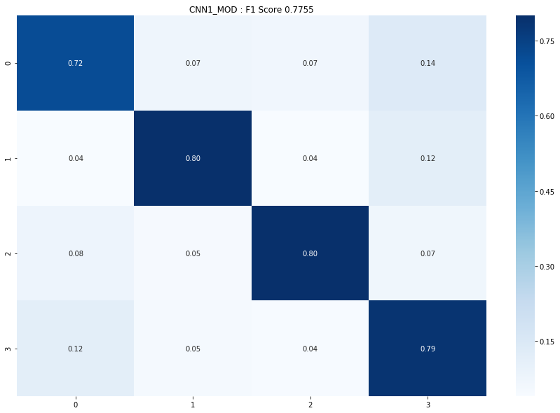

```python
summarize_net(cnn1_mod, X_test_aug, y_test, title_text = 'CNN1_MOD')
```

It turns out changing the parameters of the model actually hindered performance. The F1 score decreased by about 2 percent back to levels of the first CNN we looked at. Lets view the training and validation accuracy below and see if adding the extra dropout in the earlier help the CNN not over-fit the training data.

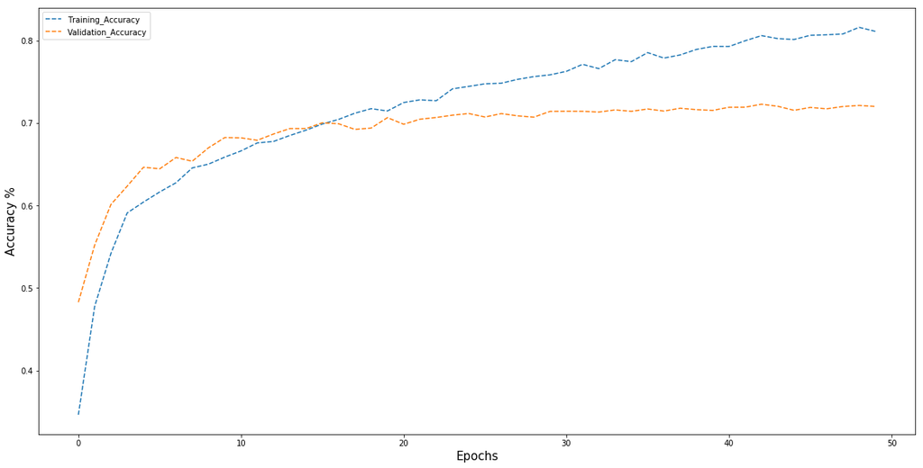

```python
%matplotlib inline
plt.figure(figsize = (20,10))
plt.plot(history_cnn1_mod['acc'], label = 'Training_Accuracy', linestyle = '--')
plt.plot(history_cnn1_mod['val_acc'], label = 'Validation_Accuracy', linestyle = '--')
plt.ylabel('Accuracy %', size = 15)
plt.xlabel('Epochs', size = 15)
plt.legend()
plt.show()
```

From the above, it is seen that the extra dropout in the early layer did not really contribute much to reducing over-fitting. The training accuracy steadily increases with the number of epochs as the validation accuracy maxes out around 71 percent and levels off. AlexNet was an good intermediate architecture to examine, however did not produce the promising results I hoped for. Lets look at an even deeper architecture and see if we can't create a better classifier.

#### 6.3 Architecture 3: LeNet Style Architecture with Resnet Style Blocks (cnn2)

The architecture below is substantially deeper and more complex than the architectures examined above. Based on the LeNet architecture, this CNN introduces three new techniques: weight initialization, L2 regularization, and ResNet style bypass blocks. By appropriately initializing the weights of the CNN, we can help the network learn. Regularization is another technique that is used to avoid model over-fitting. By incorporating bypass layers, the problem of vanishing gradients is basically eliminated. This is because now when performing back propagation, the network can go around or 'bypass', each layer as well as go through them and update the weights in the layers behind. Thus, this ensures gradients in the early layers of the network will remain large enough to meaningfully update the weights in the layers. A illustration of a ResNet style bypass block is shown below.

Lets see what this network can do!

The ResNet-Style Bypass is described in the following:

[figure not shown]

Reference: Eric Larson: http://localhost:8888/notebooks/Machine%20Learning%20In%20Python/EricLarson/12.%20More%20Advanced%20CNN%20Techniques.ipynb

```python
def create_cnn2():

    l2_lambda = 0.0001

    input_holder = Input(shape = (32,32,3))

    x = Conv2D(filters = 32,
               input_shape  = (32,32,3),
               kernel_size = (3,3),
               kernel_initializer = 'he_uniform',
               kernel_regularizer = l2(l2_lambda),
               padding = 'same',
               activation = 'relu',
               data_format = 'channels_last')(input_holder)

    x = MaxPooling2D(pool_size = (2,2), data_format = 'channels_last')(x)

    x = Conv2D(filters = 32,
               kernel_size = (3,3),
               kernel_initializer = 'he_uniform',
               kernel_regularizer = l2(l2_lambda),
               padding = 'same',
               activation = 'relu',
               data_format = 'channels_last')(x)

    x_split = MaxPooling2D(pool_size = (2,2), data_format = 'channels_last')(x)

    x = Conv2D(filters = 64,
               kernel_size = (1,1),
               kernel_initializer = 'he_uniform',
               kernel_regularizer = l2(l2_lambda),
               padding = 'same',
               activation = 'relu',
               data_format = 'channels_last')(x_split)

    x = Conv2D(filters = 64,
               kernel_size = (3,3),
               kernel_initializer = 'he_uniform',
               kernel_regularizer = l2(l2_lambda),
               padding = 'same',
               activation = 'relu',
               data_format = 'channels_last')(x)

    x = Conv2D(filters = 32,
               kernel_size = (1,1),
               kernel_initializer = 'he_uniform',
               kernel_regularizer = l2(l2_lambda),
               padding = 'same',
               activation = 'relu',
               data_format = 'channels_last')(x)

    x = Add()([x, x_split])
    x = Activation('relu')(x)
    x = MaxPooling2D(pool_size = (2,2), data_format = 'channels_last')(x)
    x = Flatten()(x)
    x = Dropout(0.25)(x)
    x = Dense(256)(x)
    x = Activation('relu')(x)
    x = Dropout(0.5)(x)
    x = Dense(n_classes)(x)
    x = Activation('softmax')(x)

    cnn2 = Model(inputs = input_holder, outputs = x)

    return cnn2

# Code Reference: Eric Larson. http://localhost:8888/notebooks/Machine%20Learning%20In%20Python/EricLarson/11.%20Convolutional%20Neural%20Networks.ipynb
```

```python
K = 2

skf = StratifiedKFold(n_splits = K, shuffle = True, random_state = 1).split(X_train_aug, y_train_aug)

F1_score_list_cnn2 = []

for i, (train, test) in enumerate(skf):
    print('Fold:', i)

    X_train_cnn2 = X_train_aug[train]
    y_train_cnn2 = to_categorical(y_train_aug[train], n_classes)
    X_test_cnn2 = X_train_aug[test]
    y_test_cnn2 = to_categorical(y_train_aug[test])

    cnn2 = create_cnn2()

    cnn2.compile(loss = 'categorical_crossentropy',
             optimizer = 'adagrad',
             metrics = ['accuracy'])

    history_cnn2 = cnn2.fit(X_train_cnn2, y_train_cnn2,
                            batch_size = 500, epochs = 50,
                            shuffle = True, verbose = 1,
                            validation_data = (X_test_cnn2, y_test_cnn2))

    yhat_cnn2 = np.argmax(cnn2.predict(X_test_cnn2), axis = 1)

    F1_score = f1_score(y_train_aug[test], yhat_cnn2, average = 'micro')

    F1_score_list_cnn2.append(F1_score)

    print('F1 Score:', F1_score)
```

```python
cnn2.save('CNN2/cnn2.h5')
pickle.dump(F1_score_list_cnn2, open('CNN2/F1_score_list_cnn2.txt', 'wb'))
pickle.dump(history_cnn2.history, open('CNN2/history_cnn2.txt', 'wb'))
```

```python
cnn2 = load_model('CNN2/cnn2.h5')
f1_score_cnn2 = pickle.load(open('CNN2/F1_score_list_cnn2.txt', 'rb'))
history_cnn2 = pickle.load(open('CNN2/history_cnn2.txt', 'rb'))
```

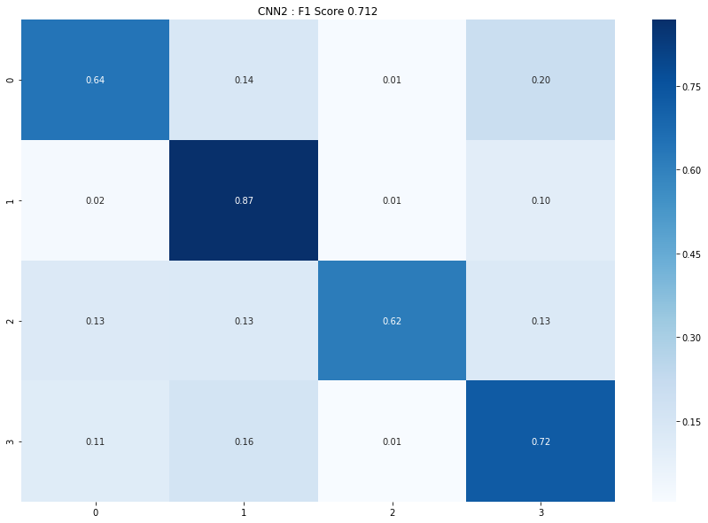

```python
summarize_net(cnn2, X_test_aug, y_test, title_text = 'CNN2')
```

EWW! Some deep network. With all its tricks this network performed worse than its simpler predecessors above. Only achieving an F1 score of 71 percent puts this in last place.

Maybe some parameter changes will fix this network and help it realize its full potential, maybe not. Lets find out below. In the network below, I made a few different changes. I varied the filter size of the convolutional layers, I changed the weight initialization to lecun_uniform, because after all this architecture was inspired from his LeNet architecture, and lastly I chose to use less dropout in the first dense layer.

###### 6.3.1 CNN2 Modified (cnn2_mod)

```python
def create_cnn2_mod():

    l2_lambda = 0.0001

    input_holder = Input(shape = (32,32,3))

    x = Conv2D(filters = 32,
               input_shape  = (32,32,3),
               kernel_size = (9,9),
               kernel_initializer = 'lecun_uniform',
               kernel_regularizer = l2(l2_lambda),
               padding = 'same',
               activation = 'relu',
               data_format = 'channels_last')(input_holder)

    x = MaxPooling2D(pool_size = (2,2), data_format = 'channels_last')(x)

    x = Conv2D(filters = 64,
               kernel_size = (6,6),
               kernel_initializer = 'lecun_uniform',
               kernel_regularizer = l2(l2_lambda),
               padding = 'same',
               activation = 'relu',
               data_format = 'channels_last')(x)

    x_split = MaxPooling2D(pool_size = (2,2), data_format = 'channels_last')(x)

    x = Conv2D(filters = 32,
               kernel_size = (6,6),
               kernel_initializer = 'lecun_uniform',
               kernel_regularizer = l2(l2_lambda),
               padding = 'same',
               activation = 'relu',
               data_format = 'channels_last')(x_split)

    x = Conv2D(filters = 128,
               kernel_size = (3,3),
               kernel_initializer = 'lecun_uniform',
               kernel_regularizer = l2(l2_lambda),
               padding = 'same',
               activation = 'relu',
               data_format = 'channels_last')(x)

    x = Conv2D(filters = 64,
               kernel_size = (1,1),
               kernel_initializer = 'lecun_uniform',
               kernel_regularizer = l2(l2_lambda),
               padding = 'same',
               activation = 'relu',
               data_format = 'channels_last')(x)

    x = Add()([x, x_split])
    x = Activation('relu')(x)
    x = MaxPooling2D(pool_size = (2,2), data_format = 'channels_last')(x)
    x = Flatten()(x)
    x = Dropout(0.1)(x)
    x = Dense(256)(x)
    x = Activation('relu')(x)
    x = Dropout(0.25)(x)
    x = Dense(n_classes)(x)
    x = Activation('softmax')(x)

    cnn2_mod = Model(inputs = input_holder, outputs = x)

    return cnn2_mod

# Code Reference: Eric Larson. http://localhost:8888/notebooks/Machine%20Learning%20In%20Python/EricLarson/11.%20Convolutional%20Neural%20Networks.ipynb
```

```python
K = 2

skf = StratifiedKFold(n_splits = K, shuffle = True, random_state = 1).split(X_train_aug, y_train_aug)

F1_score_list_cnn2_mod = []

for i, (train, test) in enumerate(skf):
    print('Fold:', i)

    X_train_cnn2_mod = X_train_aug[train]
    y_train_cnn2_mod = to_categorical(y_train_aug[train], n_classes)
    X_test_cnn2_mod = X_train_aug[test]
    y_test_cnn2_mod = to_categorical(y_train_aug[test])

    cnn2_mod = create_cnn2_mod()

    cnn2_mod.compile(loss = 'mean_squared_logarithmic_error',
             optimizer = 'adam',
             metrics = ['accuracy'])

    history_cnn2_mod = cnn2_mod.fit(X_train_cnn2_mod, y_train_cnn2_mod,
                            batch_size = 500, epochs = 50,
                            shuffle = True, verbose = 1,
                            validation_data = (X_test_cnn2_mod, y_test_cnn2_mod),
                            callbacks=[EarlyStopping(monitor='val_loss', patience=4)])

    yhat_cnn2_mod = np.argmax(cnn2_mod.predict(X_test_cnn2_mod), axis = 1)

    F1_score = f1_score(y_train_aug[test], yhat_cnn2_mod, average = 'micro')

    F1_score_list_cnn2_mod.append(F1_score)

    print('F1 Score:', F1_score)
```

```python
cnn2_mod.save('CNN2_MOD/cnn2_mod.h5')
pickle.dump(F1_score_list_cnn2_mod, open('CNN2_MOD/F1_score_list_cnn2_mod.txt', 'wb'))
pickle.dump(history_cnn2_mod.history, open('CNN2_MOD/history_cnn2_mod.txt', 'wb'))
```

```python
cnn2_mod = load_model('CNN2_MOD/cnn2_mod.h5')
f1_score_cnn2_mod = pickle.load(open('CNN2_MOD/F1_score_list_cnn2_mod.txt', 'rb'))
history_cnn2_mod = pickle.load(open('CNN2_MOD/history_cnn2_mod.txt', 'rb'))
```

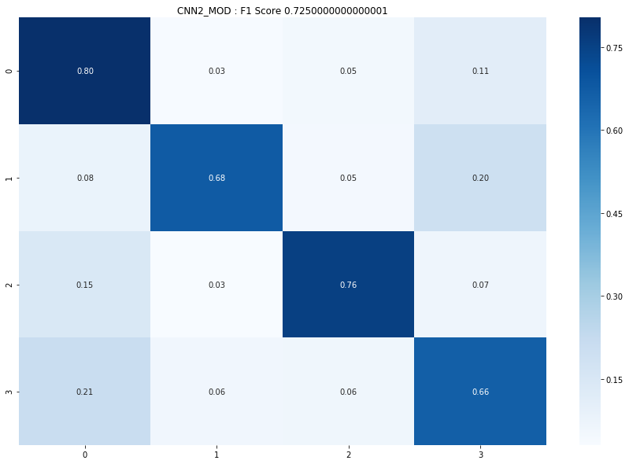

```python
summarize_net(cnn2_mod, X_test_aug, y_test, title_text = 'CNN2_MOD')
```

In changing the parameters above, we can see the F1 score marginally improved, but not by much. From both LeNet style architectures above, it is apparent that for this dataset and classification task, these deeper style architectures did not perform nearly as well as the simpler architectures I explored initially.

#### 6.4 Visualization of the Results of the Different CNN Architectures

In the visualizations below, lets look at the average f1 score over the two fold cross validation for each CNN above, and also the standard deviation of the f1 score to get a feel for the variance in the f1 score for each CNN above. Using this, I will select what I believe are the two best architectures and perform a statistical comparison of the two to find the optimal CNN for our classification task.

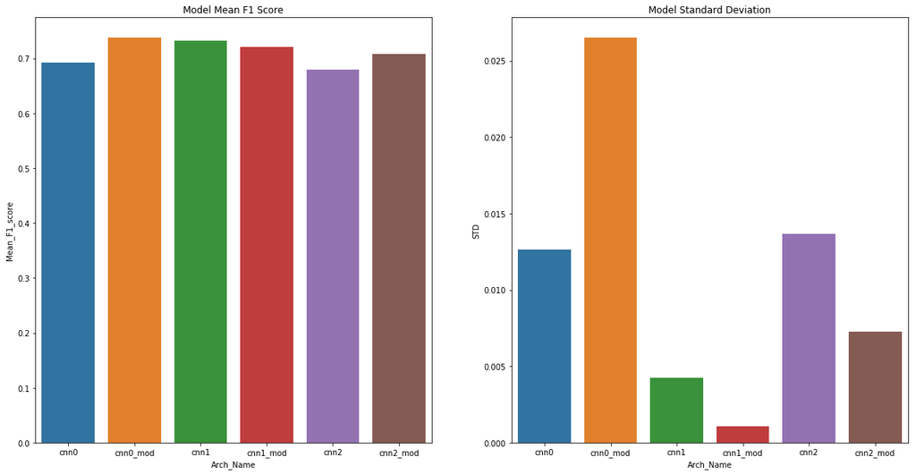

```python
arch_score = [np.mean(f1_score_cnn0),
           np.mean(f1_score_cnn0_mod),
           np.mean(f1_score_cnn1),
           np.mean(f1_score_cnn1_mod),
           np.mean(f1_score_cnn2),
           np.mean(f1_score_cnn2_mod),]

arch_std = [np.std(f1_score_cnn0),
           np.std(f1_score_cnn0_mod),
           np.std(f1_score_cnn1),
           np.std(f1_score_cnn1_mod),
           np.std(f1_score_cnn2),
           np.std(f1_score_cnn2_mod),]

arch_name = ['cnn0', 'cnn0_mod', 'cnn1', 'cnn1_mod', 'cnn2', 'cnn2_mod']

arch_compare = pd.DataFrame({'Mean_F1_score': arch_score, 'STD': arch_std, 'Arch_Name': arch_name})

f, (ax1, ax2) = plt.subplots(nrows = 1, ncols = 2, figsize=(20,10))
sns.barplot(x='Arch_Name', y='Mean_F1_score', data=arch_compare, ax=ax1)
sns.barplot(x='Arch_Name', y='STD', data=arch_compare, ax=ax2)
ax1.set_title('Model Mean F1 Score')
ax2.set_title('Model Standard Deviation')
plt.show()
```

However, from solely observing the mean f1 score and standard deviation, how sure of myself can I be when I say that cnn1_mod is the best performing CNN architecture. To find out I will perform a statistical T-Test to determine if I can say with 95% certainty that cnn1_mod is better than cnn1.

#### 6.5 Statistical Comparision of cnn1 and cnn1_mod

To statistically compare the performance of the two CNN architectures, I am going to perform a T-Test. More specifically, I will approximate the bounds using the folds of the cross fold validation to get a mean and variance of the f1 scores for the CNNs. I believe this is the most appropriate means of generating confidence intervals because both models were trained using the same data. For the T-Test, I will use a t value of 2.26 and k = 10 (note that this is lowercase k and not capital K, which indicated the number of folds in the cross validation).

If the resulting confidence interval between the two CNNs does not include 0, then statistically, with 95% confidence, we can say that the cnn1_mod CNN architecture is the better CNN.

```python
f1_score_cnn1_mod_ttest = np.array(f1_score_cnn1_mod)
f1_score_cnn1_ttest = np.array(f1_score_cnn1)

k = 10
t = 2.26 / np.sqrt(k)

e = (1 - f1_score_cnn1_mod_ttest) - (1 - f1_score_cnn1_ttest)
stdtot = np.std(e)
dbar = np.mean(e)
print(f'Confidence Interval: {dbar - t * stdtot} --> {dbar + t * stdtot}')
```

```
Confidence Interval: 0.007512223818650329 --> 0.015087776181349735
```

### 6.6 My Best CNN (cnn1_mod)

```python
def create_cnn_best():
    cnn1_mod = Sequential()
    cnn1_mod.add(Conv2D(filters = 32,
                  input_shape = (32,32,3),
                  kernel_size = (6,6),
                  padding = 'same',
                  activation = 'relu'))

    cnn1_mod.add(Conv2D(filters = 64,
                   kernel_size = (3,3),
                   padding = 'same',
                   activation = 'relu'))

    cnn1_mod.add(MaxPooling2D(pool_size = (2,2), data_format = 'channels_last'))

    cnn1_mod.add(Dropout(0.4))
    cnn1_mod.add(Flatten())
    cnn1_mod.add(Dense(64, activation = 'relu'))
    cnn1_mod.add(Dropout(0.5))
    cnn1_mod.add(Dense(n_classes, activation = 'softmax'))

    return cnn_best

# Code Reference: Eric Larson. http://localhost:8888/notebooks/Machine%20Learning%20In%20Python/EricLarson/11.%20Convolutional%20Neural%20Networks.ipynb
```

```python
K = 2

skf = StratifiedKFold(n_splits = K, shuffle = True, random_state = 1).split(X_train_aug, y_train_aug)

F1_train_fold0 = []
F1_test_fold0 = []

F1_train_fold1 = []
F1_test_fold1 = []

for i, (train, test) in enumerate(skf):
    print('Fold:', i)

    X_train_cnn_best = X_train_aug[train]
    y_train_cnn_best = to_categorical(y_train_aug[train], n_classes)
    X_test_cnn_best = X_train_aug[test]
    y_test_cnn_best = to_categorical(y_train_aug[test])

    cnn_best = create_cnn_best()

    cnn_best.compile(loss = 'categorical_crossentropy',
             optimizer = 'adagrad',
             metrics = ['accuracy'])

    if i == 0:
#         # This will get the history parameter for the CNN
#         history_cnn_best_fold0 = cnn_best.fit(X_train_cnn_best, y_train_cnn_best,
#                                     batch_size = 500, epochs = 50,
#                                     shuffle = True, verbose = 1,
#                                     validation_data = (X_test_cnn_best, y_test_cnn_best))

        # This loop will get the f1 score over the interations
        epochs = 50
        for i in range(epochs):
            cnn_best.fit(X_train_cnn_best, y_train_cnn_best,
                                    batch_size = 500, epochs = 1,
                                    shuffle = True, verbose = 1,
                                    validation_data = (X_test_cnn_best, y_test_cnn_best))

            yhat_train = np.argmax(cnn_best.predict(X_train_cnn_best), axis = 1)
            f1_score_train = f1_score(y_train_aug[train], yhat_train, average = 'micro')
            F1_train_fold0.append(f1_score_train)

            yhat_test = np.argmax(cnn_best.predict(X_test_cnn_best), axis = 1)
            f1_score_test = f1_score(y_train_aug[test], yhat_test, average = 'micro')
            F1_test_fold0.append(f1_score_test)

            print(f'F1 Score Train Fold0 {f1_score_train}')
            print(f'F1 Score Test Fold0 {f1_score_test}')

    if i == 1:
#         # This will get the history parameter for the CNN
#         history_cnn_best_fold1 = cnn_best.fit(X_train_cnn_best, y_train_cnn_best,
#                                     batch_size = 500, epochs = 50,
#                                     shuffle = True, verbose = 1,
#                                     validation_data = (X_test_cnn_best, y_test_cnn_best))

        # This loop will get the f1 score over the interations
        epochs = 50
        for i in range(epochs):
            cnn_best.fit(X_train_cnn_best, y_train_cnn_best,
                                    batch_size = 500, epochs = 1,
                                    shuffle = True, verbose = 1,
                                    validation_data = (X_test_cnn_best, y_test_cnn_best))

            yhat_train = np.argmax(cnn_best.predict(X_train_cnn_best), axis = 1)
            f1_score_train = f1_score(y_train_aug[train], yhat_train, average = 'micro')
            F1_train_fold1.append(f1_score_train)

            yhat_test = np.argmax(cnn_best.predict(X_test_cnn_best), axis = 1)
            f1_score_test = f1_score(y_train_aug[test], yhat_test, average = 'micro')
            F1_test_fold1.append(f1_score_test)

            print(f'F1 Score Train Fold1 {f1_score_train}')
            print(f'F1 Score Test Fold1 {f1_score_test}')
```

```python
cnn_best.save('CNN_BEST/cnn_best.h5')
pickle.dump(F1_train_fold0, open('CNN_BEST/F1_train_scores_fold0.txt', 'wb'))
pickle.dump(F1_test_fold0, open('CNN_BEST/F1_test_scores_fold0.txt', 'wb'))
pickle.dump(F1_train_fold1, open('CNN_BEST/F1_train_scores_fold1.txt', 'wb'))
pickle.dump(F1_test_fold1 , open('CNN_BEST/F1_test_scores_fold1.txt', 'wb'))
```

```python
cnn_best = load_model('CNN_BEST/cnn_best.h5')
F1_train_fold0 = pickle.load(open('CNN_BEST/F1_train_scores_fold0.txt', 'rb'))
F1_test_fold0 = pickle.load(open('CNN_BEST/F1_test_scores_fold0.txt', 'rb'))
F1_train_fold1 = pickle.load(open('CNN_BEST/F1_train_scores_fold1.txt', 'rb'))
F1_test_fold1 = pickle.load(open('CNN_BEST/F1_test_scores_fold1.txt', 'rb'))
```

```python
cnn_best.summary()
```

```
_________________________________________________________________
Layer (type)                 Output Shape              Param #
=================================================================
conv2d_39 (Conv2D)           (None, 32, 32, 32)        3488
_________________________________________________________________
conv2d_40 (Conv2D)           (None, 32, 32, 64)        18496
_________________________________________________________________
max_pooling2d_20 (MaxPooling (None, 16, 16, 64)        0
_________________________________________________________________
dropout_39 (Dropout)         (None, 16, 16, 64)        0
_________________________________________________________________
flatten_20 (Flatten)         (None, 16384)             0
_________________________________________________________________
dense_65 (Dense)             (None, 64)                1048640
_________________________________________________________________
dropout_40 (Dropout)         (None, 64)                0
_________________________________________________________________
dense_66 (Dense)             (None, 4)                 260
=================================================================
Total params: 1,070,884
Trainable params: 1,070,884
Non-trainable params: 0
_________________________________________________________________
```

Lets visualize the performance of my best model with respect to the f1 score on the training and validation data over the training iterations.

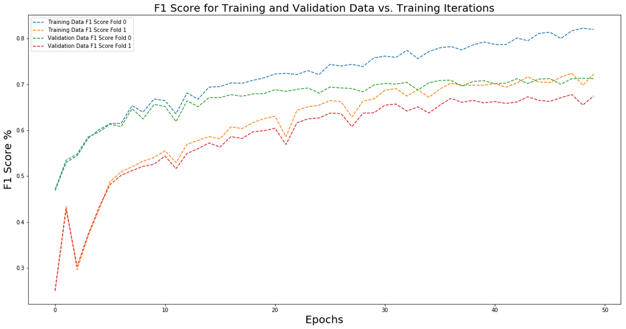

```python
%matplotlib inline
plt.figure(figsize = (20,10))

epochs = [x for x in range(50)]
plt.plot(F1_train_fold0, label = 'Training Data F1 Score Fold 0', linestyle = '--')
plt.plot(F1_train_fold1, label = 'Training Data F1 Score Fold 1', linestyle = '--')
plt.plot(F1_test_fold0, label = 'Validation Data F1 Score Fold 0', linestyle = '--')
plt.plot(F1_test_fold1, label = 'Validation Data F1 Score Fold 1', linestyle = '--')
plt.title('F1 Score for Training and Validation Data vs. Training Iterations', fontsize = 20)
plt.xlabel('Epochs', fontsize = 20)
plt.ylabel('F1 Score %', fontsize = 20)
plt.legend(loc = 'best')
```

In visualizing the training and validation f1 scores over the training iterations for both folds of the cross validation above, it is seen that over fold 0, the model seemed to slightly over-fit the training data, apparent by the continual increase in the training f1 score and the flattish behavior in the validation f1 score (after about epoch 10). However, over fold 1 the training and validation f1 scores stayed more in line with each other, with the validation f1 score slightly lagging the training f1 score.

### 6.7 Comparison to Standard MLP

```python
X_train_mlp = X_train_aug.reshape(20000, 32*32*3)
X_test_mlp = X_test_aug.reshape(2000, 32*32*3)
```

```python
def create_mlp():
    mlp = Sequential()
    mlp.add(Dense(input_dim = X_train_mlp.shape[1] , units = 30, activation='relu'))
    mlp.add(Dense(units = 15, activation='relu'))
    mlp.add(Dense(n_classes))
    mlp.add(Activation('softmax'))
    return mlp

# Code Reference: Eric Larson. http://localhost:8888/notebooks/Machine%20Learning%20In%20Python/EricLarson/11.%20Convolutional%20Neural%20Networks.ipynb
```

```python
K = 2

skf = StratifiedKFold(n_splits = K, shuffle = True, random_state = 1).split(X_train_mlp, y_train_aug)

F1_score_mlp_fold0 = []
F1_score_mlp_fold1 = []

for i, (train, test) in enumerate(skf):
    print('Fold:', i)

    X_train_smlp = X_train_mlp[train]
    y_train_smlp = to_categorical(y_train_aug[train], n_classes)
    X_test_smlp = X_train_mlp[test]
    y_test_smlp = to_categorical(y_train_aug[test])

    mlp = create_mlp()

    mlp.compile(loss = 'mean_squared_error',
               optimizer = 'rmsprop',
               metrics = ['accuracy'])
    if i == 0:
        mlp.fit(X_train_smlp, y_train_smlp, batch_size = 500,
               epochs = 50, shuffle = True, verbose = 1)
        yhat_mlp = np.argmax(mlp.predict(X_test_smlp), axis = 1)
        F1_score = f1_score(y_train_aug[test], yhat_mlp, average = 'micro')
        F1_score_mlp_fold0.append(F1_score)

    if i == 1:
        mlp.fit(X_train_smlp, y_train_smlp, batch_size = 500,
               epochs = 50, shuffle = True, verbose = 1)
        yhat_mlp = np.argmax(mlp.predict(X_test_smlp), axis = 1)
        F1_score = f1_score(y_train_aug[test], yhat_mlp, average = 'micro')
        F1_score_mlp_fold1.append(F1_score)
```

```python
mlp.save('MLP/mlp.h5')
pickle.dump(F1_score_mlp_fold0, open('MLP/F1_scores_mlp_fold0.txt', 'wb'))
pickle.dump(F1_score_mlp_fold1, open('MLP/F1_scores_mlp_fold1.txt', 'wb'))
```

```python
mlp = load_model('MLP/mlp.h5')
f1_score_mlp_fold0 = pickle.load(open('MLP/F1_scores_mlp_fold0.txt', 'rb'))
f1_score_mlp_fold1 = pickle.load(open('MLP/F1_scores_mlp_fold1.txt', 'rb'))
```

```python
mlp.summary()
```

```
_________________________________________________________________
Layer (type)                 Output Shape              Param #
=================================================================
dense_76 (Dense)             (None, 30)                92190
_________________________________________________________________
dense_77 (Dense)             (None, 15)                465
_________________________________________________________________
dense_78 (Dense)             (None, 4)                 64
_________________________________________________________________
activation_12 (Activation)   (None, 4)                 0
=================================================================
Total params: 92,719
Trainable params: 92,719
Non-trainable params: 0
_________________________________________________________________
```

```python
def compare_cnn_mlp(cnn, mlp, X_test_cnn, X_test_mlp, y_test):
    plt.figure(figsize =(20,5))
    if cnn is not None:
        yhat = np.argmax(cnn.predict(X_test_cnn), axis = 1)
        f1 = f1_score(y_test, yhat, average = 'micro')
        plt.subplot(1,2,1)
        cm = confusion_matrix(y_test, yhat)
        cm = cm/np.sum(cm, axis = 1)[:, np.newaxis]
        sns.heatmap(cm, annot = True, fmt = '.2f', cmap = 'Blues')
        plt.title(f'My_Best_CNN: F1 Score {f1}')

    if mlp is not None:
        yhat = np.argmax(mlp.predict(X_test_mlp), axis = 1)
        f1 = f1_score(y_test, yhat, average = 'micro')
        plt.subplot(1,2,2)
        cm = confusion_matrix(y_test, yhat)
        cm = cm/np.sum(cm, axis = 1)[:, np.newaxis]
        sns.heatmap(cm, annot = True, fmt = '.2f', cmap = 'Blues')
        plt.title(f'Standard MLP : F1 Score {f1}')

# Code Reference: Eric Larson. http://localhost:8888/notebooks/Machine%20Learning%20In%20Python/EricLarson/11.%20Convolutional%20Neural%20Networks.ipynb
```

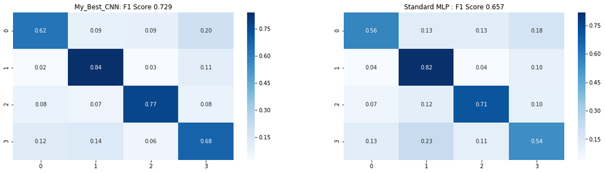

```python
compare_cnn_mlp(cnn_best, mlp, X_test_aug, X_test_mlp , y_test)
```

From the above, the MLP achieved an f1 score of 65.7 %, lower than any of the other CNNs explored above, while my best CNN achieved an f1 score of 72.9 %. Both model were best at classifying people and trees, class 1 and 2, respectively. While comparing the confusion matrices is a nice initial glance at the classification performance of these two models, lets take a more in depth look below.

###### 6.7.1 Reciever Operating Characteristic and Area Under the Curve

Below, we are going to look at the Receiver Operating Characteristic (ROC) curve and the Area Under the Curve (AUC) as one method to compare a Standard MLP to my best CNN. ROC curves are useful tools which to aid in selecting classification models based on their performance with respect to the False Positive Rate and True Positive Rate. ROC curves are constructed by shifting the decision threshold of the classifier, and counting the number of True Positives and False Positives both above and below the threshold. The diagonal of an ROC curve represents random guessing, while a perfect classifier would have a True Positive Rate of 1 and a False Positive Rate if 0, represented in the ROC curve below. Once an ROC curve has been calculated, more information can be derived from the AUC to characterize the classification performance of a model, with a greater AUC commonly indicating a better model[3].

Below, lets compute and graphically examine the ROC and AUC of a Standard MLP and my best CNN.

[3] Raschka, Sebastian & Mirkalili, Vahid. Python Machine Learning.

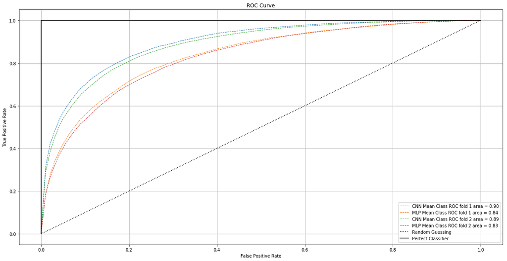

```python
%matplotlib inline
plt.figure(figsize = (20,10))

K = 2
skf = StratifiedKFold(n_splits = K, shuffle = True, random_state = 1).split(X_train_aug, y_train_aug)

mean_tpr = 0.0
mean_fpr = np.linspace(0, 1, 100)
all_tpr = []

for i, (train, test) in enumerate(skf):

    X_train_cnn = X_train_aug[train]
    X_test_cnn = X_train_aug[test]
    y_train_cnn = to_categorical(y_train_aug[train], n_classes)
    y_test_cnn = to_categorical(y_train_aug[test], n_classes)

    X_test_smlp = X_train_mlp[test]


    pred_cnn = cnn_best.predict(X_test_cnn)

    pred_mlp = mlp.predict(X_test_smlp)

    # CNN
    perclass_mean_tpr = 0.0
    roc_auc = 0
    classes = np.unique(y_train_aug)

    for j in classes:
        fpr, tpr, thresholds = roc_curve(y_train_aug[test],
                                         pred_cnn[:,j],
                                         pos_label = j)
        perclass_mean_tpr += interp(mean_fpr, fpr, tpr)
        perclass_mean_tpr[0] = 0.0
        roc_auc += auc(fpr,tpr)

    perclass_mean_tpr /= len(classes)
    roc_auc /= len(classes)
    mean_tpr += perclass_mean_tpr

    plt.plot(mean_fpr, perclass_mean_tpr, '--', lw = 1, label = 'CNN Mean Class ROC fold %d area = %0.2f' % (i + 1, roc_auc))

    # MLP
    perclass_mean_tpr = 0.0
    roc_auc = 0
    classes = np.unique(y_train_aug)

    for j in classes:
        fpr, tpr, thresholds = roc_curve(y_train_aug[test],
                                         pred_mlp[:,j],
                                         pos_label = j)
        perclass_mean_tpr += interp(mean_fpr, fpr, tpr)
        perclass_mean_tpr[0] = 0.0
        roc_auc += auc(fpr,tpr)

    perclass_mean_tpr /= len(classes)
    roc_auc /= len(classes)
    mean_tpr += perclass_mean_tpr

    plt.plot(mean_fpr, perclass_mean_tpr, '--', lw = 1, label = 'MLP Mean Class ROC fold %d area = %0.2f' % (i + 1, roc_auc))

# The following code is taken and slightly modified from Raschka, Sebastian & Mirkalili, Vahid. Python Machine Learning.
plt.plot([0,1], [0,1], linestyle = ':', color = 'black', label = 'Random Guessing')

plt.plot([0,0,1], [0,1,1], linestyle = '-', color = 'black', label = 'Perfect Classifier' )

plt.grid()
plt.xlabel('False Positive Rate', fontsize = 10)
plt.ylabel('True Positive Rate', fontsize = 10)
plt.title('ROC Curve')
plt.legend(loc = 'best', fontsize = 10)
plt.show()
```

Using the ROC curve and AUC, lets come to a determination of which classifier is the better choice for the classification task at hand. Please note the perfect classifier and random guessing curves plotted in the graph above.

In examining the ROC curve, it can be determined that the my best CNN is the better classifier compared to the Standard MLP. This is apparent by the CNN ROC curves being closer to that of a perfect classifier over both folds. Also, the average AUC over the two folds for the my best CNN was 0.895, while the average AUC over the two folds for the Standard MLP was 0.835.

Since there is no overlap between any of the curves, there is not really any further considerations necessary from the ROC curve and AUC in comparing the performance of the two classifiers, since my best CNN has obvious better classification performance in terms of it's ROC curves and average AUC.

###### 6.7.2 Statistical Comparision

Lets again, determine how certain we can be when we say that my best CNN is the better classifier compared to the Standard MLP. To determine if we can say with 95% certainty that my best CNN is the better classifier, let again perform the same T-Test we performed in section 6.5.

However, in this T-Test I am going to compare the models over both cross validation folds.

```python
best_cnn_f1_scores_fold0 = F1_test_fold0
best_cnn_f1_scores_fold1 = F1_test_fold1
```

```python
best_cnn_f1_scores_fold0 = np.array(best_cnn_f1_scores_fold0)
best_cnn_f1_scores_fold1 = np.array(best_cnn_f1_scores_fold1)
f1_scores_mlp_fold0 = np.array(f1_score_mlp_fold0)
f1_scores_mlp_fold1 = np.array(f1_score_mlp_fold1)
```

```python
k = 10
t = 2.26 / np.sqrt(k)

efold0 = (1 - best_cnn_f1_scores_fold0) - (1 - f1_scores_mlp_fold0)
stdtotfold0 = np.std(e)
dbarfold0 = np.mean(e)
print(f'Confidence Interval over fold 0: {dbarfold0 - t * stdtotfold0} --> {dbarfold0 + t * stdtotfold0}')

efold1 = (1 - best_cnn_f1_scores_fold1) - (1 - f1_scores_mlp_fold1)
stdtotfold1 = np.std(e)
dbarfold1 = np.mean(e)
print(f'Confidence Interval over fold 1: {dbarfold1 - t * stdtotfold1} --> {dbarfold1 + t * stdtotfold1}')
```

```
Confidence Interval over fold 0: 0.007512223818650329 --> 0.015087776181349735
Confidence Interval over fold 1: 0.007512223818650329 --> 0.015087776181349735
```

# 7. Transfer Learning

In the following section, I am going to explore a transfer learning technique to pre-train the weights in the convolutinal layers of the CNN created below. Using this technique, we can use the weights of pre-trained verifiable convolutional neural networks, such as VGG16, ResNet, or Xception, to name a few, to initialize the weights in the initial convolutional layers of CNNs we want to create, thus only having to train the weights in the dense layers.

For this particular example, I am going to use the 'imagenet' weights from ResNet50 to initialize the weights of the convolutional layers in the CNN I create below. Then I will take the output of the pre-trained convolutional layers from ResNet50 and place them through two dense layers.

```python
from keras.applications.resnet50 import ResNet50
from keras.applications.xception import Xception
from keras.preprocessing import image
from keras.applications.resnet50 import preprocess_input, decode_predictions
from scipy.misc import imresize
from skimage.transform import resize
```

res_model = ResNet50(weights = 'imagenet')

```python
X_train_upsample = [imresize(x,size= (224,224,3), interp = 'nearest') for x in X_train_aug]
X_test_upsample = [imresize(x,size= (224,224,3), interp = 'nearest') for x in X_test_aug]
X_train_up = np.stack(X_train_upsample, axis = 0)
X_test_up = np.stack(X_test_upsample, axis = 0)

print(X_train_up.shape)
print(X_test_up.shape)
```

```
(20000, 224, 224, 3)
(2000, 224, 224, 3)
```

```python
x = res_model.output

x = Dense(64, activation='relu', kernel_initializer='lecun_uniform')(x)
predictions = Dense(n_classes, activation='softmax', kernel_initializer='glorot_uniform')(x)

model = Model(inputs = res_model.input, outputs = predictions)

# Do not train resnet layers
for layer in res_model.layers:
    layer.trainable = False

model.compile(optimizer = 'rmsprop', loss = 'categorical_crossentropy', metrics = ['accuracy'])
```

```python
model.fit(X_train_up[:10000],y_train_aug_ohe[:10000],epochs=1,batch_size=500,verbose=1)
```

One epoch only took 35 minutes to train!

```python
model.save('TransferLearningModel/model.h5')
```

```python
model = load_model('TransferLearningModel/model.h5')
```

```python
model.summary()
```

```
__________________________________________________________________________________________________
Layer (type)                    Output Shape         Param #     Connected to
==================================================================================================
input_3 (InputLayer)            (None, 224, 224, 3)  0
__________________________________________________________________________________________________
conv1_pad (ZeroPadding2D)       (None, 230, 230, 3)  0           input_3[0][0]
__________________________________________________________________________________________________
conv1 (Conv2D)                  (None, 112, 112, 64) 9472        conv1_pad[0][0]
__________________________________________________________________________________________________
bn_conv1 (BatchNormalization)   (None, 112, 112, 64) 256         conv1[0][0]
__________________________________________________________________________________________________
activation_62 (Activation)      (None, 112, 112, 64) 0           bn_conv1[0][0]
__________________________________________________________________________________________________
max_pooling2d_22 (MaxPooling2D) (None, 55, 55, 64)   0           activation_62[0][0]
__________________________________________________________________________________________________
res2a_branch2a (Conv2D)         (None, 55, 55, 64)   4160        max_pooling2d_22[0][0]
__________________________________________________________________________________________________
bn2a_branch2a (BatchNormalizati (None, 55, 55, 64)   256         res2a_branch2a[0][0]
__________________________________________________________________________________________________
activation_63 (Activation)      (None, 55, 55, 64)   0           bn2a_branch2a[0][0]
__________________________________________________________________________________________________
res2a_branch2b (Conv2D)         (None, 55, 55, 64)   36928       activation_63[0][0]
__________________________________________________________________________________________________
bn2a_branch2b (BatchNormalizati (None, 55, 55, 64)   256         res2a_branch2b[0][0]
__________________________________________________________________________________________________
activation_64 (Activation)      (None, 55, 55, 64)   0           bn2a_branch2b[0][0]
__________________________________________________________________________________________________
res2a_branch2c (Conv2D)         (None, 55, 55, 256)  16640       activation_64[0][0]
__________________________________________________________________________________________________
res2a_branch1 (Conv2D)          (None, 55, 55, 256)  16640       max_pooling2d_22[0][0]
__________________________________________________________________________________________________
bn2a_branch2c (BatchNormalizati (None, 55, 55, 256)  1024        res2a_branch2c[0][0]
__________________________________________________________________________________________________
bn2a_branch1 (BatchNormalizatio (None, 55, 55, 256)  1024        res2a_branch1[0][0]
__________________________________________________________________________________________________
add_29 (Add)                    (None, 55, 55, 256)  0           bn2a_branch2c[0][0]
                                                                 bn2a_branch1[0][0]
__________________________________________________________________________________________________
activation_65 (Activation)      (None, 55, 55, 256)  0           add_29[0][0]
__________________________________________________________________________________________________
```

[output cut: 326 more lines]

[output not shown]

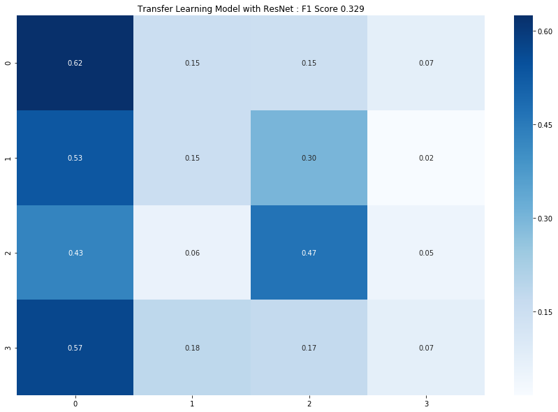

```python
summarize_net(model, X_test_up , y_test, title_text = 'Transfer Learning Model with ResNet')
```

#### 7.1 Comparison of Transfer Learning to Training from Scratch

This is sort of an unfair comparison at the moment because the CNN trained from scratch (my best CNN) was able to train for 50 epochs, while the CNN used in the transfer learning model was only able to train for 1 epoch. But, what if we wanted to get a fair assessment of how these two models actually compare. Lets level the playing field a bit. Since I do not have the resources to train the transfer learning model for 50 epochs, lets instead only train the CNN in my best CNN for 1 epoch and over the same 10,000 instances and see how the models compare.

It should also be noted that the transfer learning CNN was trained on 224 x 224 x 3 images because this is the size of images ResNet50 was trained on as well, so lets also reflect this is the CNN trained from scratch.

```python
def create_cnn_scratch():
    cnn_scratch = Sequential()
    cnn_scratch.add(Conv2D(filters = 32,
                  input_shape = (224,224,3),
                  kernel_size = (6,6),
                  padding = 'same',
                  activation = 'relu'))

    cnn_scratch.add(Conv2D(filters = 64,
                   kernel_size = (3,3),
                   padding = 'same',
                   activation = 'relu'))

    cnn_scratch.add(MaxPooling2D(pool_size = (2,2), data_format = 'channels_last'))

    cnn_scratch.add(Dropout(0.4))
    cnn_scratch.add(Flatten())
    cnn_scratch.add(Dense(64, activation = 'relu'))
    cnn_scratch.add(Dropout(0.5))
    cnn_scratch.add(Dense(n_classes, activation = 'softmax'))

    return cnn_scratch
```

```python
cnn_scratch = create_cnn_scratch()
cnn_scratch.compile(optimizer = 'rmsprop', loss = 'categorical_crossentropy', metrics = ['accuracy'])
cnn_scratch.fit(X_train_up[:10000],y_train_aug_ohe[:10000],epochs=1,batch_size=500,verbose=1)
```

```
<keras.callbacks.History at 0x1318a5cc0>
```

```python
cnn_scratch.save('CNN_SCRATCH/cnn_scratch.h5')
```

Now that we have leveled the playing field between the two models lets compare two models in terms of classification performance.

```python
def compare_scratch_transer(cnn, trans, X_test, y_test):
    plt.figure(figsize =(20,5))
    if cnn is not None:
        yhat = np.argmax(cnn.predict(X_test), axis = 1)
        f1 = f1_score(y_test, yhat, average = 'micro')
        plt.subplot(1,2,1)
        cm = confusion_matrix(y_test, yhat)
        cm = cm/np.sum(cm, axis = 1)[:, np.newaxis]
        sns.heatmap(cm, annot = True, fmt = '.2f', cmap = 'Blues')
        plt.title(f'CNN from Scratch : F1 Score {f1}')

    if trans is not None:
        yhat = np.argmax(trans.predict(X_test), axis = 1)
        f1 = f1_score(y_test, yhat, average = 'micro')
        plt.subplot(1,2,2)
        cm = confusion_matrix(y_test, yhat)
        cm = cm/np.sum(cm, axis = 1)[:, np.newaxis]
        sns.heatmap(cm, annot = True, fmt = '.2f', cmap = 'Blues')
        plt.title(f'Transfer Learning : F1 Score {f1}')

# Helper function used to plot the confusion matricies of the CNN's in this assignment.
```

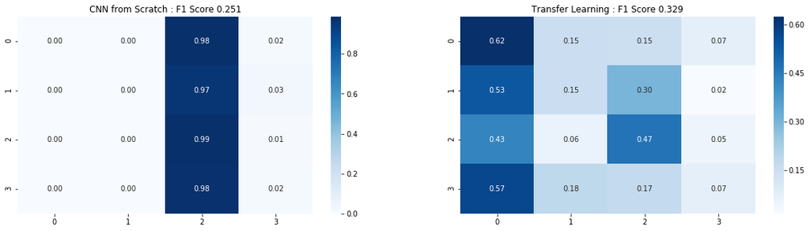

```python
compare_scratch_transer(cnn_scratch, model, X_test_up, y_test)
```

We can see now that the cnn from scratch and the transfer learning model have been trained over the same exact upscaled images and for the same number of epochs. From this, the transfer learning model seems to be the better classifier in terms of classification performance and f1 measure. Off the bat with one epoch of training, the transfer learning model was able achieve a classification accuracy of 62% in class 0 and 47% in class 2, thats not horrible! On the contrary, the cnn from scratch after one training iteration basically classified all images ass class 2, which really means it is guessing all images belong to the same class.

Let's really examine the classification performance of these two models by taking a look at the ROC curve and AUC for the both models.

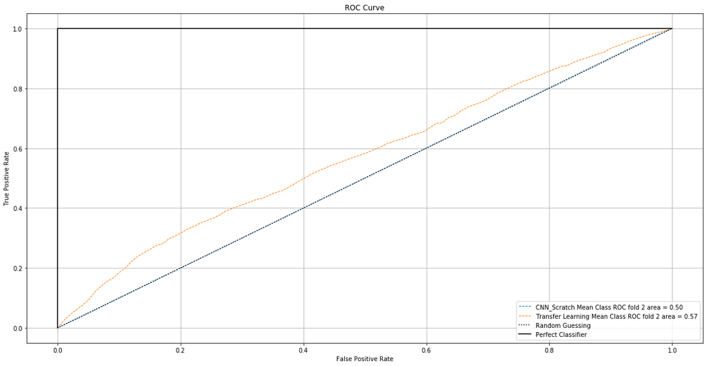

```python
%matplotlib inline
plt.figure(figsize = (20,10))

mean_tpr = 0.0
mean_fpr = np.linspace(0, 1, 100)
all_tpr = []

pred_cnn = cnn_scratch.predict(X_test_up)

pred_trans = model.predict(X_test_up)

# CNN
perclass_mean_tpr = 0.0
roc_auc = 0
classes = np.unique(y_train_aug)

for j in classes:
    fpr, tpr, thresholds = roc_curve(y_test,
                                     pred_cnn[:,j],
                                     pos_label = j)
    perclass_mean_tpr += interp(mean_fpr, fpr, tpr)
    perclass_mean_tpr[0] = 0.0
    roc_auc += auc(fpr,tpr)

perclass_mean_tpr /= len(classes)
roc_auc /= len(classes)
mean_tpr += perclass_mean_tpr

plt.plot(mean_fpr, perclass_mean_tpr, '--', lw = 1, label = 'CNN_Scratch Mean Class ROC fold %d area = %0.2f' % (i + 1, roc_auc))

# Trans
perclass_mean_tpr = 0.0
roc_auc = 0
classes = np.unique(y_train_aug)

for j in classes:
    fpr, tpr, thresholds = roc_curve(y_test,
                                     pred_trans[:,j],
                                     pos_label = j)
    perclass_mean_tpr += interp(mean_fpr, fpr, tpr)
    perclass_mean_tpr[0] = 0.0
    roc_auc += auc(fpr,tpr)

perclass_mean_tpr /= len(classes)
roc_auc /= len(classes)
mean_tpr += perclass_mean_tpr

plt.plot(mean_fpr, perclass_mean_tpr, '--', lw = 1, label = 'Transfer Learning Mean Class ROC fold %d area = %0.2f' % (i + 1, roc_auc))

# The following code is taken and slightly modified from Raschka, Sebastian & Mirkalili, Vahid. Python Machine Learning.
plt.plot([0,1], [0,1], linestyle = ':', color = 'black', label = 'Random Guessing')

plt.plot([0,0,1], [0,1,1], linestyle = '-', color = 'black', label = 'Perfect Classifier' )

plt.grid()
plt.xlabel('False Positive Rate', fontsize = 10)
plt.ylabel('True Positive Rate', fontsize = 10)
plt.title('ROC Curve')
plt.legend(loc = 'best', fontsize = 10)
plt.show()
```

This graph really says it all. Keep in mind this is only after 1 epoch! After the single training iteration the CNN trained from scratch is basically randomly guessing the classes of the images. This is also reassured by the confusion matrix for the CNN trained from scratch above, where it classified all images as class 2. But look! The transfer learning CNN after the same 1 epoch is actually starting to obtain some classification performance. While it is far from the curve of a perfect classifier, it certainly beats the CNN trained from scratch in terms of classification performance.

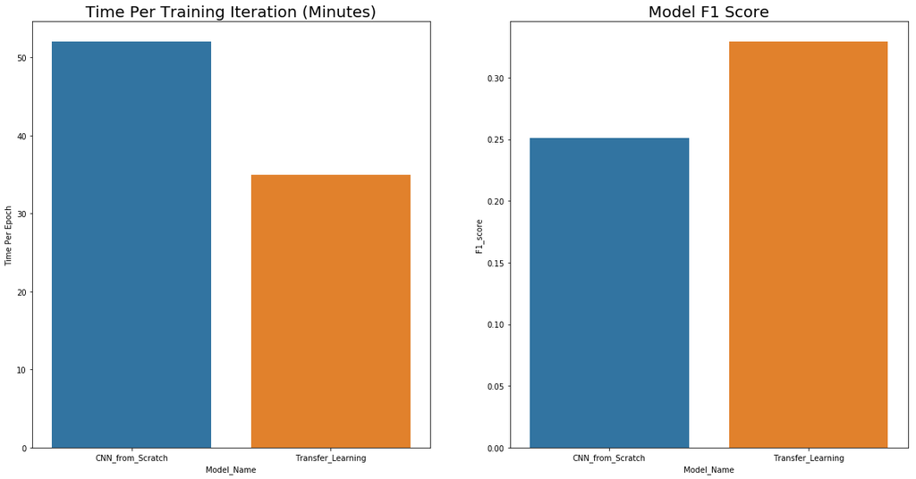

```python
time_per_epoch = [52, 35] # in minutes [my_best_model, transfer_model]
f1_scores = [0.251, 0.329]

m_name = ['CNN_from_Scratch', 'Transfer_Learning']

compare = pd.DataFrame({'Time Per Epoch': time_per_epoch, 'F1_score': f1_scores, 'Model_Name': m_name})

f, (ax1, ax2) = plt.subplots(nrows = 1, ncols = 2, figsize=(20,10))
sns.barplot(x='Model_Name', y='Time Per Epoch', data=compare, ax=ax1)
sns.barplot(x='Model_Name', y='F1_score', data=compare, ax=ax2)
ax1.set_title('Time Per Training Iteration (Minutes)', fontsize = 20)
ax2.set_title('Model F1 Score', fontsize = 20)
plt.show()
```

I thought it would be an interesting comparison to look at the training time per epoch and f1 score these two models were able to achieve after the one epoch. From this, it is apparent that the transfer learning model seems like it has the potential to be the better classifier once again. It took only about 35 minutes per epoch to train, 17 minutes less than it took to train the CNN from scratch for the same 1 epoch. Also, with only 1 epoch the transfer learning model was actually able to start classifying some images, and had an f1 score of 32%, while the CNN from scratch had an f1 score of 25 % after 1 epoch and really just classified everything as class 2.

# 8. Closing Thoughts

The purpose of this lab was to create a CNN that could be deployed and used in autonomous driving vehicles to help them classify objects in their surroundings. The dataset I used to train and test the CNNs created above was the CIFAR-100 dataset, which looking back is really an innapropraite dataset to use in this scenario. It consists on tiny thumbnail images which are not quite realistic in what a car would actually see while driving around. While, I was able to argue a case for why it could be plausable, it really is not ideal data to use. I believe more appropraite data to use to train classifiers of self driving cars would be still frames video content captured on the cameras of self driving cars, with corresponding labels for objects in the frames.

Due to the misuse of this data for this classification task, I would never deploy this model for use in a self driving car. Also, I really believe for use in a self driving car these models should achieve a much higher generalization performance than the model in this assigment were able to achieve.